# Analyzing Tree Health Using G-LiHT Data

Aliya & Minh

4/5/2021

# Working with Point Cloud

In order to create a dataframe for our tree healthy analysis, we first read all las files from client data folder. Since there were 5 regions (mid, north, south1, south2 and south3), we created a loop to combined the las files into one large las file (main) and added the correct region attribute of the main las file. The last step was to reproject the shapefile that we created on ArcMap to our main las file. To do this, we created a get_las_crowns function. The function takes in two arguments (first argument = las file, second argument = shape file) and provide a las file with treeid and shape id while removing all elements with “NA” treeid.

Note: Shape id was permanently written onto our las file using add_lasattribute. This allows us to retain a unique id for each of our tree if we ever need it. Treeid attribute was not retained when we write our las file since it is non-numeric.

## Auto-read Las Files

```r
sfm_all <- list.files(path = "../../STV/project_data/point_clouds/",
                      pattern = "las$", full.names = TRUE) %>% c()
```

```r
## Import LAS file (using the paths specified above)

for (i in seq_along(sfm_all)) {
  if(i==1) {
    start_time <- Sys.time()
    las_all <- list()
  }

  las_all[[str_replace_all(str_match(sfm_all[i], "\\_\\w*\\_"),"\\_|sfm", "")]] <- lidR::readLAS(sfm_all[i]) %>%
    add_attribute(str_replace_all(str_match(sfm_all[i], "\\_\\w*\\_"),"\\_|sfm", ""), "region")

  if(i==length(sfm_all)) {
    las_all <- do.call(rbind,las_all)
    end_time <- Sys.time()
    print(paste0("Processing Time: ", end_time - start_time)) # 26.8120880126953 secs
  }

}
```

```
## [1] "Processing Time: 25.1879379749298"
```

## Reproject Shapefile to Las File

```r
# Created get_las_crowns function (first argument = las file, second argument = shape file)

get_las_crowns <- function(las, shape) {

  start_time <- Sys.time()

  las_crs <- crs(las, asText = FALSE)
  fhm_crowns_reproj <- spTransform(shape,las_crs)
  las_extent <- extent(las)
  fhm_crowns_shp_sub <- crop(fhm_crowns_reproj, las_extent)

  # for points that land within each polygon, add the "treeid" attribute from the shapefile to the las dataset
  all_las_crowns <- merge_spatial(las, fhm_crowns_shp_sub, "treeid") # filter such that only points within the polygons remains
  all_las_crowns <- merge_spatial(all_las_crowns, fhm_crowns_shp_sub, "Id") # add in id - comment out to reduce time

  all_las_crowns <- filter_poi(all_las_crowns, treeid != "NA") # filter out NA treeid

  all_las_crowns <<- add_lasattribute(all_las_crowns, all_las_crowns@data$Id, "Id", "Shape ID#") # add Id as a las attribute into the las file - "extra bytes"

  end_time <- Sys.time()
  time <- paste0("Processing Time: ", end_time - start_time)
  output <- list(time, all_las_crowns)

  return(output)
}

get_las_crowns(las_all, fhm_crowns_shp) # 7.99595518509547 mins (LAS dimension: 233153 rows x23 columns)
```

# Reading Files (Shape, Las and CSV)

```r
#sfm_dir <- "C:/Users/Minh Nguyen/ENVS_RS Dropbox/Projects/pix4d/201807XX_Denali_FHM_06/"

#Read in hand drawn crowns shapefile for cal/val
#fhm_crowns_shp <- readOGR(paste0(sfm_dir, "../../Alaska/fhm_2018_uav/ak_spruce_crowns.shp"))
fhm_crowns_shp <- readOGR("../../Alaska/fhm_2018_uav/ak_spruce_crowns.shp")
# Read in LAS file
#all_las_crowns <- readLAS(paste0(sfm_dir, "../../STV/code/R/AliyaMinh/data/all_las_crowns.las"))
all_las_crowns <- readLAS("../../STV/code/R/AliyaMinh/data/all_las_crowns.las")
# Not needed unless you want to process the las files again and re-add treeid (already in the raw_df)
all_las_crowns <- merge_spatial(all_las_crowns, fhm_crowns_shp, "treeid") # filter such that only points within the polygons remains

# Read in csv and las files
#raw_df <- read.csv(paste0(sfm_dir, "../../STV/code/R/AliyaMinh/data/raw_df.csv")) %>%
raw_df <- read.csv( "../../STV/code/R/AliyaMinh/data/raw_df.csv") %>%
  mutate(region = as.factor(region),
         status = as.factor(status))

#missing_df <- read.csv(paste0(sfm_dir, "../../STV/code/R/AliyaMinh/data/missing_df.csv")) %>%
missing_df <- read.csv("../../STV/code/R/AliyaMinh/data/missing_df.csv") %>%
  mutate(confirmed = as.factor(confirmed))
```

# Descriptive Analysis

We started our analysis by checking our point cloud data. We looked at height (Z) and status. Though the points do not directly tell us anything, it is always good to know what our data is comprised of before delving any deeper. You will notice that in our raw data frame we have three statuses (A=Alive, G=Green and D=Dead). However, the goal was to focus on Alive vs Dead so all Green points/trees were removed. For more on basic analysis of our point cloud, please look at the descriptive.R file.

```r
# Missing Trees
missing_trees <- missing_df %>% filter(confirmed == 0)
missing_trees[1] # HWY3_53D, HWY3_52D, HWY2_30A, HWY2_29D, HWY2_28G, HWY4_62A, HWY5_103A, HWY5_100A, HWY5_101A, HWY5_102A, HWY5_99A, HWY5_97A, HWY5_98G, HWY5_90A, HWY5_92G
```

```
##      tree_id
## 1   HWY3_53D
## 2   HWY3_52D
## 3   HWY2_30A
## 4   HWY2_29D
## 5   HWY2_28G
## 6   HWY4_62A
## 7  HWY5_103A
## 8  HWY5_100A
## 9  HWY5_101A
## 10 HWY5_102A
## 11  HWY5_99A
## 12  HWY5_97A
## 13  HWY5_98G
## 14  HWY5_90A
## 15  HWY5_92G
```

```r
# Status
summary(raw_df$status)
```

```
##     A     D     G
## 60340 73866 98947
```

```r
# Height of points
summary(raw_df$Z)
```

```
##    Min. 1st Qu.  Median    Mean 3rd Qu.    Max.
##  -1.340   6.243  10.760  10.331  14.416  29.496
```

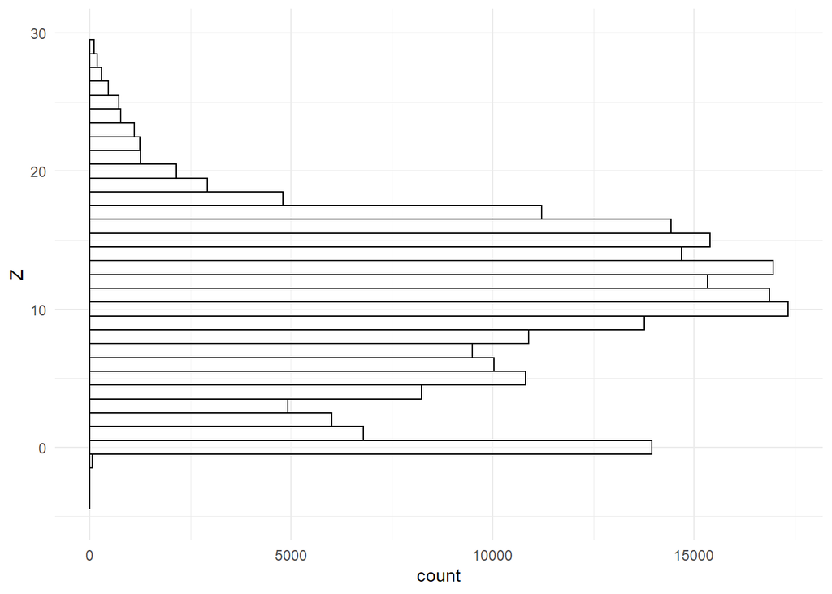

```r
# this will plot the Z values and flip the histogram 90 degrees to make it more intuitive since we're examining elevations/heights
ggplot(data=raw_df, aes(x=Z)) + geom_histogram(color= "black", fill="transparent", alpha=0.5, position="identity", binwidth = 1) +  theme_minimal() + coord_flip() + xlim(-5,30)
```

We randomly chose one Alive and one Dead tree to check our assumption that Alive trees would have more Green at higher height than Dead trees. Below are the Alive and Dead trees’ 3d plot.

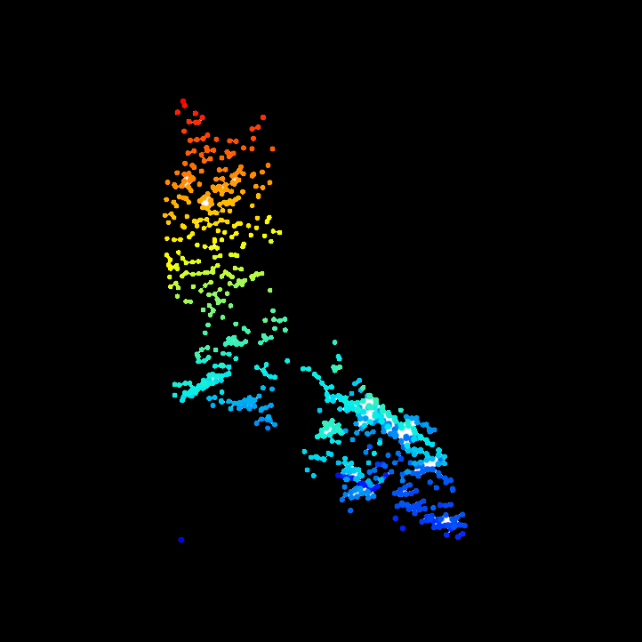

Alive

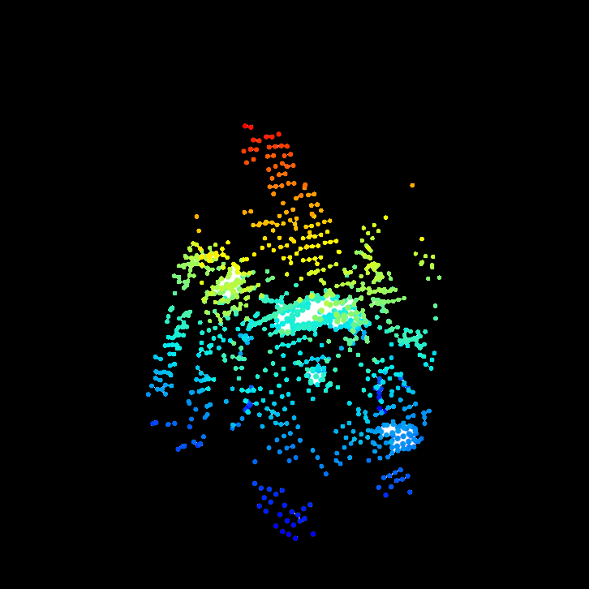

Dead

The 2 randomly selected trees were HWY5_112A (Alive) and HWY4_64D (Dead). Below are the plots showing the point distribution for G and R.

```r
unique(all_las_crowns@data$treeid)
```

```
##   [1] "HWY5_113G" "HWY5_112A" "HWY5_108G" "HWY5_110D" "HWY5_109G" "HWY5_111A"
##   [7] "HWY5_107A" "HWY5_106A" "HWY5_105A" "HWY4_87A"  "HWY4_86G"  "HWY4_88A"
##  [13] "HWY4_79A"  "HWY4_78D"  "HWY4_74D"  "HWY4_75D"  "HWY4_73D"  "HWY4_77A"
##  [19] "HWY4_72D"  "HWY4_71A"  "HWY4_70D"  "HWY4_69A"  "HWY4_68G"  "HWY4_67G"
##  [25] "HWY4_64D"  "HWY4_61A"  "HWY4_63A"  "HWY4_66D"  "HWY4_65A"  "HWY5_95A"
##  [31] "HWY5_96D"  "HWY5_93A"  "HWY5_94A"  "HWY5_91D"  "HWY5_98A"  "HWY5_104A"
##  [37] "EH_152G"   "EH_151G"   "EH_148G"   "EH_134G"   "EH_144G"   "EH_143G"
##  [43] "EH_147G"   "EH_135G"   "EH_145G"   "EH_146G"   "EH_136G"   "EH_149G"
##  [49] "EH_150G"   "EH_141G"   "EH_142G"   "EH_140G"   "EH_137G"   "EH_139G"
##  [55] "EH_138A"   "EH_131G"   "EH_130G"   "EH_129G"   "EH_132G"   "EH_117G"
##  [61] "EH_128G"   "EH_133G"   "EH_118G"   "EH_127G"   "EH_125A"   "EH_120G"
##  [67] "EH_126A"   "EH_119G"   "EH_123G"   "EH_124A"   "EH_121G"   "EH_122G"
##  [73] "HWY1_9D"   "HWY1_7d"   "HWY1_8A"   "HWY1_10A"  "HWY1_6D"   "HWY1-5G"
##  [79] "HWY1_4G"   "HYW1_3A"   "HWY1_1D"   "HWY2_2D"   "HWY2_1A"   "HWY2_5D"
##  [85] "HWY2_4A"   "HWY2_3G"   "HWY2_6D"   "HWY2_7A"   "HWY2_12G"  "HWY2_13A"
##  [91] "HWY2_9D"   "HWY2_11G"  "HWY2_10G"  "HWY2_8A"   "HWY2_16D"  "HWY2_17G"
##  [97] "HWY2_23D"  "HWY2_24G"  "HWY2_25D"  "HWY2_20D"  "HWY2_22A"  "HWY2_19D"
## [103] "HWY2_21A"  "HWY2_18A"  "HWY2_26A"  "HWY2_27G"  "TC_114G"   "TC_115G"
## [109] "TC_116G"   "HWY3_59D"  "HWY3_60G"  "HWY3_32A"  "HWY3_31A"  "HWY3_36A"
## [115] "HWY3_33A"  "HWY3_46G"  "HWY3_41A"  "HWY3_40G"  "HWY3_47G"  "HWY3_38G"
## [121] "HWY3_54A"  "HWY3_39G"  "HWY3_34A"  "HWY3_35D"  "HWY3_37G"  "HWY3_48D"
## [127] "HWY3_49A"  "HWY3_50D"  "HWY3_51D"  "HWY3_42D"  "HWY3_43A"  "HWY3_44A"
## [133] "HWY3_45D"  "HWY3_55D"  "HWY3_56A"  "HWY3_57D"  "HWY3_58A"
```

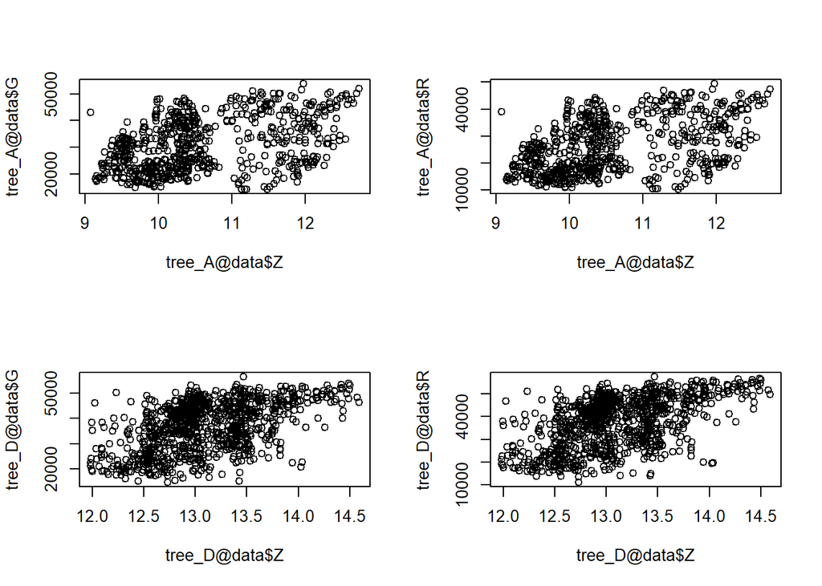

```r
tree_A <- filter_poi(all_las_crowns, treeid == "HWY5_112A")
tree_D <- filter_poi(all_las_crowns, treeid == "HWY4_64D")
#plot(tree_G, size = 8, bg = "white")
#plot(tree_D, size = 8, bg = "white")

# plot vertical structure of this tree
#dev.new(); hist(tree@data$Z)

# plot green and red at different height for Alive and Dead trees as example of a potential variable of interest
par(mfrow=c(2,2))
plot(tree_A@data$Z, tree_A@data$G)
plot(tree_A@data$Z,tree_A@data$R)
plot(tree_D@data$Z, tree_D@data$G)
plot(tree_D@data$Z,tree_D@data$R)
```

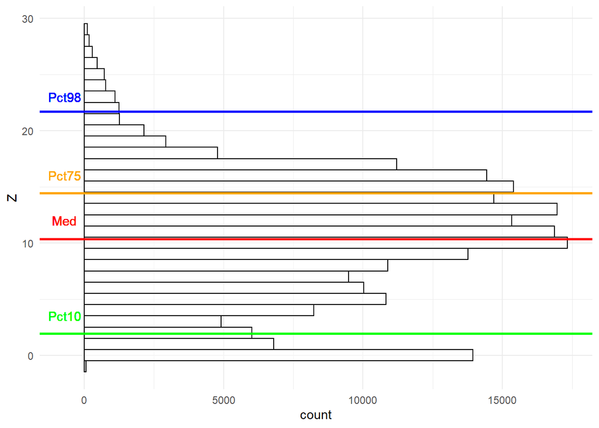

```r
# mean and median height of points in this las file also percentile (or quantile) heights.
# For example, what is the Z value below which 90% of points exist ("pct90") in this study area?
raw_df_summary <- raw_df %>% summarise(mean=mean(Z), pct10=quantile(Z,.1), pct30=quantile(Z,.3),
                    median=median(Z), pct75=quantile(Z,.75), pct90=quantile(Z,.90), pct98=quantile(Z,.98))

# histogram with pct10, mean, and pct90 plotted on top with green, red, and orange lines respectively
ggplot(data=raw_df, aes(x=Z)) + geom_histogram(color= "black", fill="transparent", alpha=0.5, position="identity", binwidth = 1) +  theme_minimal() + coord_flip() +
  geom_vline(aes(xintercept = mean(Z)),col='red',size=1) + # <-- this line is at the mean height
  geom_text(aes(x=12, label="Med", y=-700), colour="red", text=element_text(size=10)) +
  geom_vline(aes(xintercept = quantile(Z,0.1)),col='green',size=1) + # <-- this line is at pct10 height
  geom_text(aes(x=3.5, label="Pct10", y=-700), colour="green", text=element_text(size=10)) +
  geom_vline(aes(xintercept = quantile(Z,0.75)),col='orange',size=1) + # <-- this line is at pct75 height
  geom_text(aes(x=16, label="Pct75", y=-700), colour="orange", text=element_text(size=10)) +
  geom_vline(aes(xintercept = quantile(Z,0.98)),col='blue',size=1) + # <-- this line is at pct98 height
  geom_text(aes(x=23, label="Pct98", y=-700), colour="blue", text=element_text(size=10))
```

```r
#show all the quantile values calculated above
raw_df_summary
```

```
##       mean pct10 pct30 median  pct75   pct90 pct98
## 1 10.33125  1.92 7.465  10.76 14.416 16.8058 21.67
```

# Pre-Processing and Feature Extraction

From our point cloud data, we extracted features using x, y, z, red, green and blue values. Our variables/features vary from quantile value to skewness to ratio of the original point cloud values.

```r
model_df <- raw_df %>%
  group_by(treeid) %>%
  #find color statistics
  mutate(height = max(Z),
         ht_mean = mean(Z),
         ht_skw_Sp = skewness(Z),
         ht_kurt_sp = kurtosis(Z),
         ht_75p = as.numeric(quantile(Z, 0.75)),
         ht_90p = as.numeric(quantile(Z, 0.9)),
         ht_98p = as.numeric(quantile(Z, 0.98)),
         green_75p = mean(G[Z >= ht_75p]),
         green_90p = mean(G[Z >= ht_90p]),
         green_98p = mean(G[Z >= ht_98p]),
         red_75p = mean(R[Z >= ht_75p]),
         red_90p = mean(R[Z >= ht_90p]),
         red_98p = mean(R[Z >= ht_98p]),
         blue_75p = mean(B[Z >= ht_75p ]),
         blue_90p = mean(B[Z >= ht_90p]),
         blue_98p = mean(B[Z >= ht_98p]),
         greenness_75p = mean(G[Z >= ht_75p]/(R[Z >= ht_75p]+B[Z >= ht_75p])),
         greenness_90p = mean(G[Z >= ht_90p]/(R[Z >= ht_90p]+B[Z >= ht_90p])),
         greenness_98p = mean(G[Z >= ht_98p]/(R[Z >= ht_98p]+B[Z >= ht_98p])),
         redness_75p = mean(R[Z >= ht_75p]/(G[Z >= ht_75p]+B[Z >= ht_75p])),
         redness_90p = mean(R[Z >= ht_90p]/(G[Z >= ht_90p]+B[Z >= ht_90p])),
         redness_98p = mean(R[Z >= ht_98p]/(G[Z >= ht_98p]+B[Z >= ht_98p])),
         blueness_75p = mean(B[Z >= ht_75p]/(G[Z >= ht_75p]+R[Z >= ht_75p])),
         blueness_90p = mean(B[Z >= ht_90p]/(G[Z >= ht_90p]+R[Z >= ht_90p])),
         blueness_98p = mean(B[Z >= ht_98p]/(G[Z >= ht_98p]+R[Z >= ht_98p])),
         med_height = median(Z),
         blueness_mean = mean((B - G)/(B + G)),
         greenness_mean = mean((G - R)/(G + R)),
         redness_mean = mean((R - B)/(R + B)),
         blueness_std = sd((B - G)/(B + G)),
         greenness_std = sd((G - R)/(G + R)),
         redness_std = sd((R - B)/(R + B)),
         blueness_med = median((B - G)/(B + G)),
         greenness_med = median((G - R)/(G + R)),
         redness_med = median((R - B)/(R + B)),
         blueness_skw = skewness((B - G)/(B + G)),
         greenness_skw = skewness((G - R)/(G + R)),
         redness_skw = skewness((R - B)/(R + B)),
         #find overall brightness statistics
         brightness_mean = mean(B + G + R),
         brightness_med = median(B + G + R),
         brightness_std = sd(B + G + R),
         brightness_skw = skewness(B + G + R),
         #find normalized statistics
         red_norm_mean = mean(R / (R + G + B)),
         blue_norm_mean = mean(B / (R + G + B)),
         green_norm_mean = mean(G / (R + G + B)),
         R = mean(R),
         G = mean(G),
         B = mean(B),
         R_ratio = R/(R + G + B ),
         G_ratio = G/(R + G + B ),
         B_ratio = B/(R + G + B ),
         G_R_ratio = G/R,
         G_R_ratio_2 = (G - R)/(G + R))%>%
  dplyr::select(Id, treeid, status, region, R:G_R_ratio_2)
```

To simplify our dataset and speed up our models, we transformed our point cloud to one row per tree by grouping the dataset with treeid.

```r
model_df <-model_df %>% group_by(treeid) %>%
  filter(row_number()==1) %>%
  as.data.frame() %>%
  dplyr::select(-c(treeid, Id, region))

model_df <- model_df %>%
  filter(status != "G") %>%
  mutate(status = factor(status))
```

## Summary of our new dataframe

The final data frame to be used in our models has 80 observations: 47 Alive (A) and 33 Dead (D) trees, 58.75% and 41.25% respectively.

We will be using Accuracy and Kappa Coefficient of Agreement to compare our models in subsequent sections. Kappa essentially lets us know how much better are our models (information/algorithmic efficiency) than chance.

Below are the summary of all of the features extracted:

```r
descriptives(model_df, vars = vars(status), freq = TRUE)
```

```
##
##  DESCRIPTIVES
##
##  Descriptives
##  ---------------------
##               status
##  ---------------------
##    N              80
##    Missing         0
##    Mean
##    Median
##    Minimum
##    Maximum
##  ---------------------
##
##
##  FREQUENCIES
##
##  Frequencies of status
##  --------------------------------------------------
##    Levels    Counts    % of Total    Cumulative %
##  --------------------------------------------------
##    A             47      58.75000        58.75000
##    D             33      41.25000       100.00000
##  --------------------------------------------------
```

```r
summary(model_df)
```

```
##  status       R               G               B             height
##  A:47   Min.   : 9951   Min.   :16838   Min.   :12296   Min.   : 0.323
##  D:33   1st Qu.:26510   1st Qu.:30393   1st Qu.:20156   1st Qu.:11.951
##         Median :30315   Median :33255   Median :22977   Median :16.166
##         Mean   :29537   Mean   :32579   Mean   :22792   Mean   :15.142
##         3rd Qu.:33744   3rd Qu.:36830   3rd Qu.:25546   3rd Qu.:18.209
##         Max.   :43594   Max.   :43731   Max.   :33357   Max.   :29.496
##     ht_mean           ht_skw_Sp         ht_kurt_sp          ht_75p
##  Min.   :-0.05389   Min.   :-4.7649   Min.   :-1.8164   Min.   : 0.091
##  1st Qu.: 6.20253   1st Qu.:-0.6821   1st Qu.:-0.9159   1st Qu.: 7.800
##  Median :11.09913   Median :-0.1875   Median :-0.3433   Median :13.767
##  Mean   :10.29690   Mean   :-0.1751   Mean   : 1.0199   Mean   :12.091
##  3rd Qu.:14.22916   3rd Qu.: 0.4391   3rd Qu.: 0.5013   3rd Qu.:15.510
##  Max.   :17.91066   Max.   : 3.3629   Max.   :33.9043   Max.   :23.374
##      ht_90p            ht_98p          green_75p       green_90p
##  Min.   : 0.1337   Min.   : 0.1734   Min.   :16828   Min.   :16993
##  1st Qu.:10.2245   1st Qu.:11.0813   1st Qu.:31417   1st Qu.:31705
##  Median :14.8341   Median :15.6268   Median :35797   Median :37141
##  Mean   :13.4254   Mean   :14.4573   Mean   :34869   Mean   :35645
##  3rd Qu.:16.7111   3rd Qu.:17.5486   3rd Qu.:39965   3rd Qu.:41088
##  Max.   :26.4470   Max.   :28.5066   Max.   :45509   Max.   :48784
##    green_98p        red_75p         red_90p         red_98p
##  Min.   :16786   Min.   : 9905   Min.   :10411   Min.   :10709
##  1st Qu.:30815   1st Qu.:28473   1st Qu.:28154   1st Qu.:26789
##  Median :37601   Median :33515   Median :35761   Median :35433
##  Mean   :35635   Mean   :32200   Mean   :33122   Mean   :33195
##  3rd Qu.:41395   3rd Qu.:37365   3rd Qu.:38469   3rd Qu.:39538
##  Max.   :49091   Max.   :43630   Max.   :48095   Max.   :52175
##     blue_75p        blue_90p        blue_98p     greenness_75p
##  Min.   :12319   Min.   :12278   Min.   :12442   Min.   :0.5459
##  1st Qu.:21946   1st Qu.:22450   1st Qu.:20038   1st Qu.:0.5749
##  Median :25008   Median :25304   Median :25749   Median :0.6377
##  Mean   :24481   Mean   :24978   Mean   :24806   Mean   :0.6284
##  3rd Qu.:27562   3rd Qu.:28476   3rd Qu.:29793   3rd Qu.:0.6642
##  Max.   :34643   Max.   :35759   Max.   :38120   Max.   :0.7673
##  greenness_90p    greenness_98p     redness_75p      redness_90p
##  Min.   :0.5378   Min.   :0.5378   Min.   :0.3378   Min.   :0.3475
##  1st Qu.:0.5693   1st Qu.:0.5733   1st Qu.:0.5053   1st Qu.:0.5118
##  Median :0.6322   Median :0.6307   Median :0.5450   Median :0.5472
##  Mean   :0.6273   Mean   :0.6300   Mean   :0.5309   Mean   :0.5341
```

[output cut: 43 more lines]

```
##  Max.   : 2.37676   Max.   :0.3754   Max.   :0.3321   Max.   :0.4449
##     R_ratio          G_ratio          B_ratio         G_R_ratio
##  Min.   :0.2533   Min.   :0.3553   Min.   :0.1971   Min.   :0.9657
##  1st Qu.:0.3363   1st Qu.:0.3648   1st Qu.:0.2584   1st Qu.:1.0320
##  Median :0.3485   Median :0.3897   Median :0.2725   Median :1.1344
##  Mean   :0.3444   Mean   :0.3852   Mean   :0.2704   Mean   :1.1251
##  3rd Qu.:0.3580   3rd Qu.:0.3992   3rd Qu.:0.2826   3rd Qu.:1.1792
##  Max.   :0.3752   Max.   :0.4380   Max.   :0.3290   Max.   :1.7120
##   G_R_ratio_2
##  Min.   :-0.01744
##  1st Qu.: 0.01575
##  Median : 0.06296
##  Mean   : 0.05606
##  3rd Qu.: 0.08221
##  Max.   : 0.26254
```

We also checked some of our basic assumptions here:

- Total Green Count (A vs D)
  - You can see that Alive trees appear to have higher Green values
- Greenness (ratio of green) at 75% and 90%
  - Alive trees appear to have a more “normal” Greeness distribution with peak around 0.65
  - Dead trees appear to be skewed to the right with most of the Greeness less than 0.6
- Height Comparison (A vs D)
  - Alive trees appear to be less sparse
- Height at 75% and 90%
  - Alive trees appear to be less sparse at both 75% and 90% height

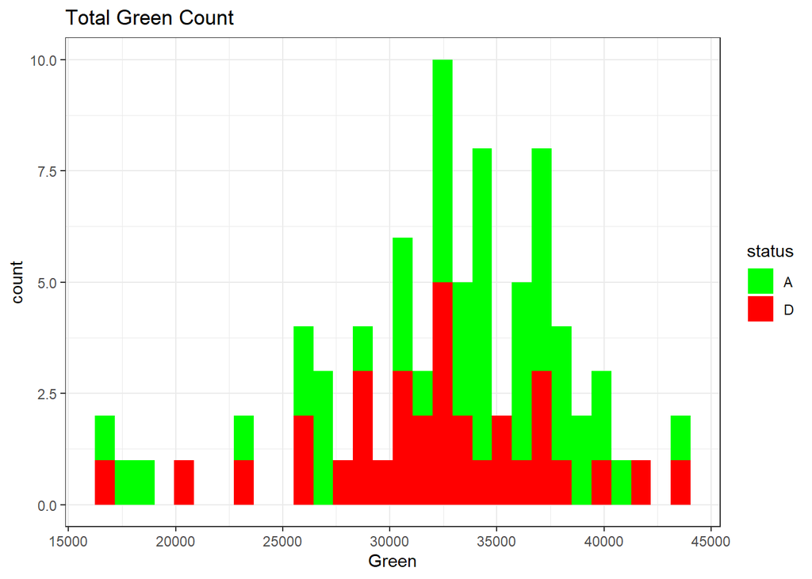

```r
model_df %>%
  ggplot(aes(x = G, fill=status)) +
  geom_histogram() +
  scale_colour_manual(values = c("green", "red"),
  aesthetics = c("colour", "fill")) +
  labs(title="Total Green Count", x="Green")
```

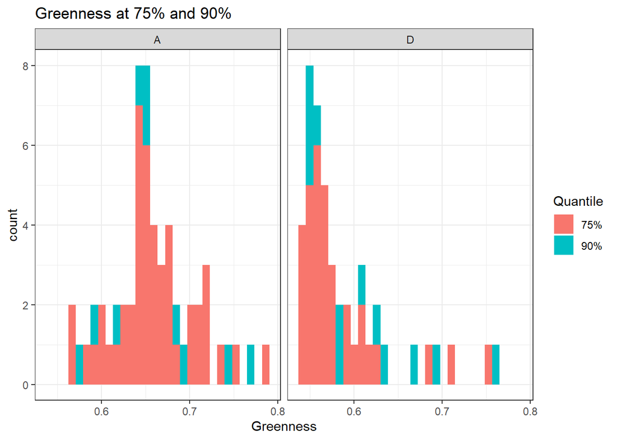

```r
model_df %>%
  ggplot() +
  geom_histogram(aes(x = greenness_75p, fill = "orange")) +
  geom_histogram(aes(x = greenness_90p, fill = "blue")) +
  labs(title="Greenness at 75% and 90%", x="Greenness") +
  scale_fill_discrete(labels = c("75%", "90%")) +
  guides(fill=guide_legend(title="Quantile")) +
  facet_wrap(~status)
```

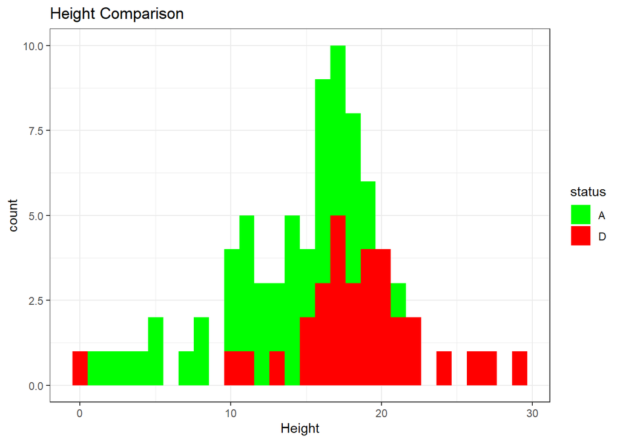

```r
model_df %>%
  ggplot(aes(x = height, fill=status)) +
  geom_histogram() +
  scale_colour_manual(values = c("green", "red"),
  aesthetics = c("colour", "fill")) +
  labs(title="Height Comparison", x="Height")
```

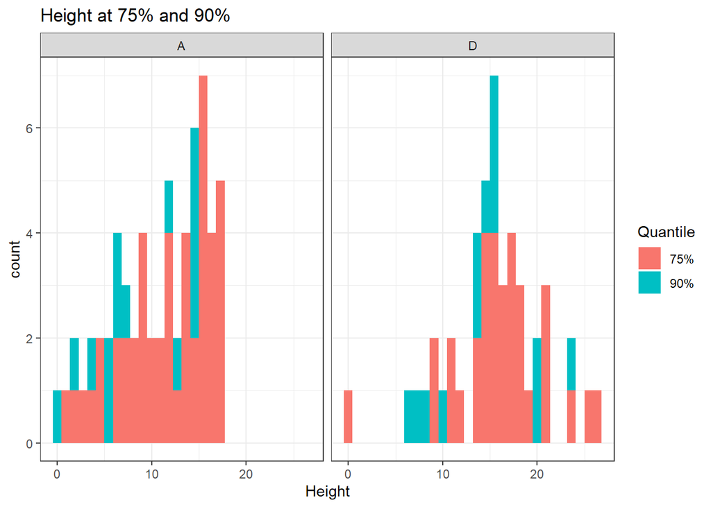

```r
model_df %>%
  ggplot() +
  geom_histogram(aes(x = ht_75p, fill = "orange")) +
  geom_histogram(aes(x = ht_90p, fill = "blue")) +
  labs(title="Height at 75% and 90%", x="Height") +
  scale_fill_discrete(labels = c("75%", "90%")) +
  guides(fill=guide_legend(title="Quantile")) +
  facet_wrap(~status)
```

## Checking Multicolinearity

It is hard to fully see our multicolinearity issue in the plot below due to having too many variables. However, you can clearly see the strong blue (positive correlation) and red (negative correlation) in the plot.

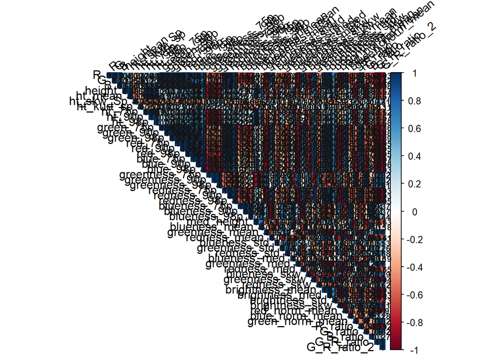

```r
corr <- as.data.frame(model_df) %>%
  dplyr::select(-status) %>% # loading dplyr because raster package causing issues
  cor()

corrplot(cor(corr), method="color", type = "upper", tl.col="black",tl.srt=40, addCoef.col = "gray8", diag = T, number.cex = 0.65)
```

# Variable Selection

Linear model has distinct advantages in terms of inference and, on real - world problems, is often surprisingly competitive in relation to non -linear methods. Hence, before moving to the non linear world, we will look at what we have from two aspects :

- `Prediction accuracy`: Looking at our dataset, number of observation is not much larger than p, then there can be a lot of variability in the least squares fit resulting in overfitting and consequently poor predictions on future observations not used in the training model.By constraining or shrinking the estimated coefficients, we can often substantially reduce the variance at the cost of a negligible increase in bias. This can lead to substantial improvements in the accuracy with which we can predict the response for observation not used in model training.
- `Model interpretability`: It is often the case that some of many of the variables used in a multiple regression model are in fact not associated with the response. Including such irrelevant variables leads to unnecessary complexity in the resulting model. By removing these variables - that is, by setting corresponding coefficient estimates to zero - we can obtain a model that is more easily interpreted.

Here, I am evaluating some of the variable selection, shrinkage methods to reduce the dimension in our dataset.

What other methods:

## 1) Best Subset Selection

The number of possible models that must be considered grows rapidly as p increases. In general there are 2p models that involve subset of p predictors. So if p = 45 we are looking at:

```r
2^45   # computationally expensive
```

```
## [1] 3.518437e+13
```

For computational reason, best subset selection cannot be applied with very large p - an enormous search space can lead to overfitting and high variance of the coefficient estimates.

So, stepwise methods are, which explore a far more restricted set of models, are attractive alternative to best subset selection.

## 2) Forward stepwise

Forward stepwise: begins with a model containing no predictors, and then adds predictors to the model, one at a time, until all of the predictors are in the model. In particular, at each step the variable that gives the greatest additional improvement to the fit is added to the model.

```r
reg.fit.fwd <- regsubsets(status~.,data = model_df,nvmax=53,method = "forward")
```

```
## Reordering variables and trying again:
```

```r
reg.fwd.summary <- summary(reg.fit.fwd)
```

Plots:

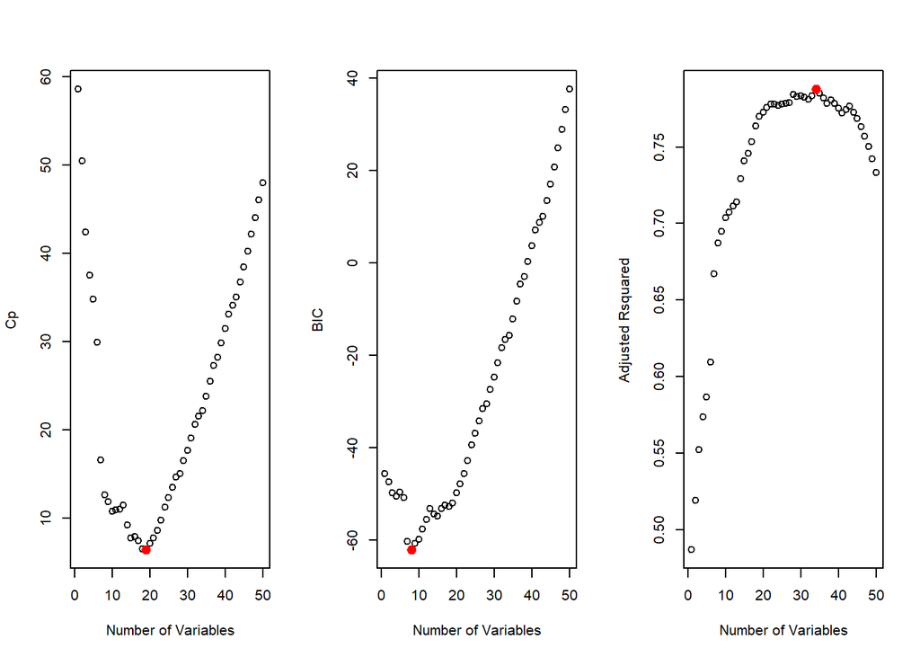

```r
par(mfrow=c(1,3))

plot(reg.fwd.summary$cp, xlab = ' Number of Variables ' , ylab = 'Cp')
# which.min(reg.fwd.summary$cp)  # min at 19
points(19, reg.fwd.summary$cp[19], col = "red",cex =2, pch = 20)

# which.min(reg.fwd.summary$bic)  #min at 8
plot(reg.fwd.summary$bic, xlab = ' Number of Variables ' , ylab = 'BIC')
points(8, reg.fwd.summary$bic[8], col = "red",cex =2, pch = 20)


plot(reg.fwd.summary$adjr2, xlab = ' Number of Variables ' , ylab = 'Adjusted Rsquared')
# which.max(reg.fwd.summary$adjr2) # max at 34
points(34, reg.fwd.summary$adjr2[34], col = "red",cex =2, pch = 20)
```

Cp, BIC, and adjusted Rsquared are shown for the best models of each size for model_df dataset. Cp and BIC are estimates of test MSE.

Mallow Cp is decreasing first at hit its lowest at 19 variables.

BIC, also decreases first and at its lowest at 8 or 10 then start increasing.

Adjusted R squared has sharp increases up until around 20 and reach its maximum around 33-34 then it starts to decline.

Plotting forward variables:

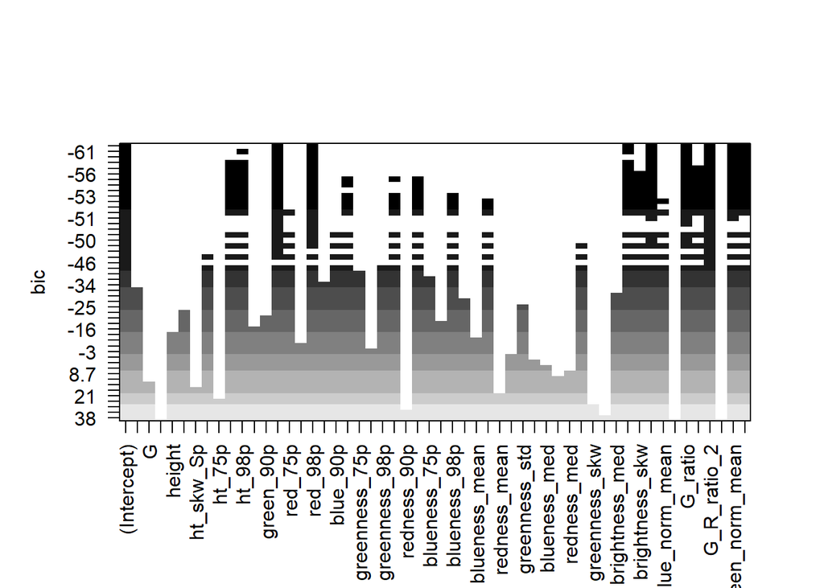

```r
plot(reg.fit.fwd)  # region north,R,  G, ht_75p
```

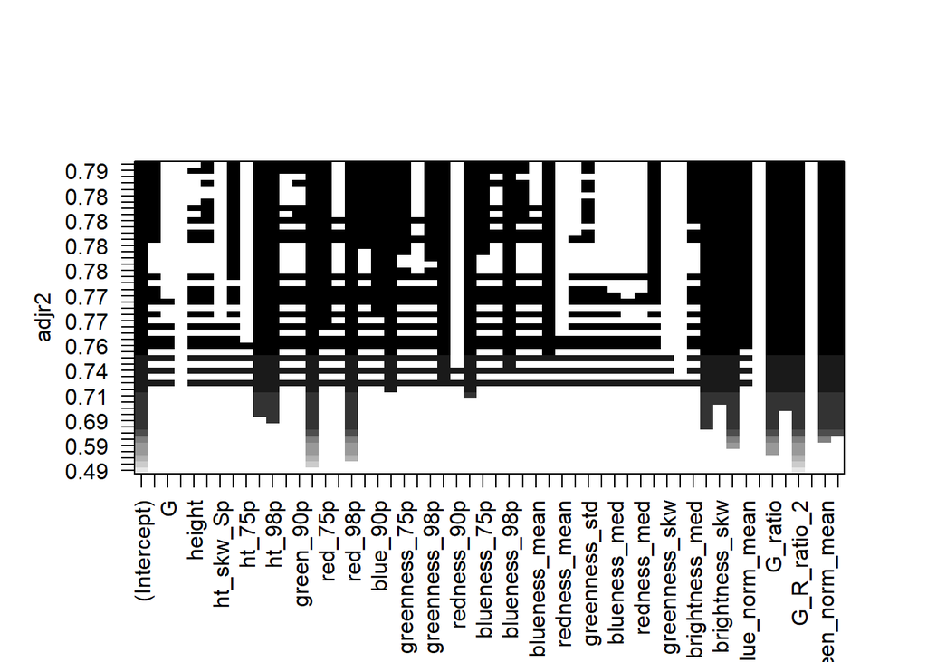

```r
plot(reg.fit.fwd, scale = "adjr2") # region north, region sount2, region south3, R,G, ht_90p, blueness_med, redness_skw, brightness_skw, R_ratio, ht_mean
```

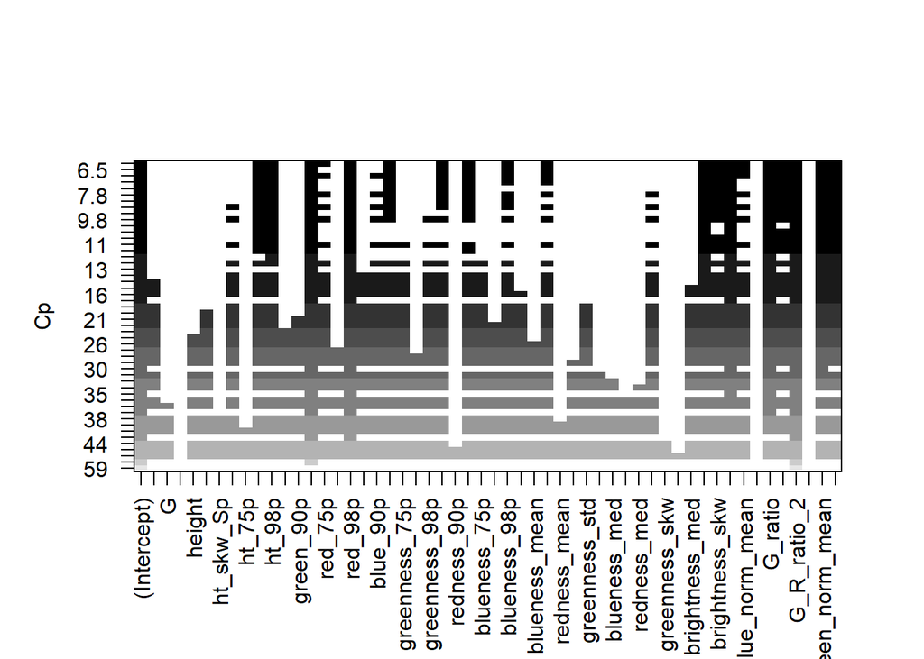

```r
plot(reg.fit.fwd, scale = "Cp")
```

```r
coef(reg.fit.fwd,9)
```

```
##     (Intercept)          ht_98p       green_98p         red_98p  brightness_std
##    3.623810e+01    2.935217e-03   -6.475091e-05    5.022388e-05   -2.976639e-06
##   red_norm_mean         G_ratio     G_R_ratio_2 green_norm_mean         B_ratio
##    8.290817e+00   -1.268065e+02    2.648762e+01    4.859879e+01   -3.133284e+01
```

## 3) Backward stepwise

Unlike forward, backward begins with the full least squares model containing all p predictors, and then iteratively remove the least useful predictor, one at a time.Problem with this method, since it starts with the over-identified model, it may suffer dimentionality issues as we remove variables, some variables that were not significant may become significant if added again.

Backward selection requires that the number of samples n is larger than the number of variables p ( so the full model can be fit). In contrast, forward stepwise can be used even when n<p, and so is the only viable subset method when p is large.

[output not shown]

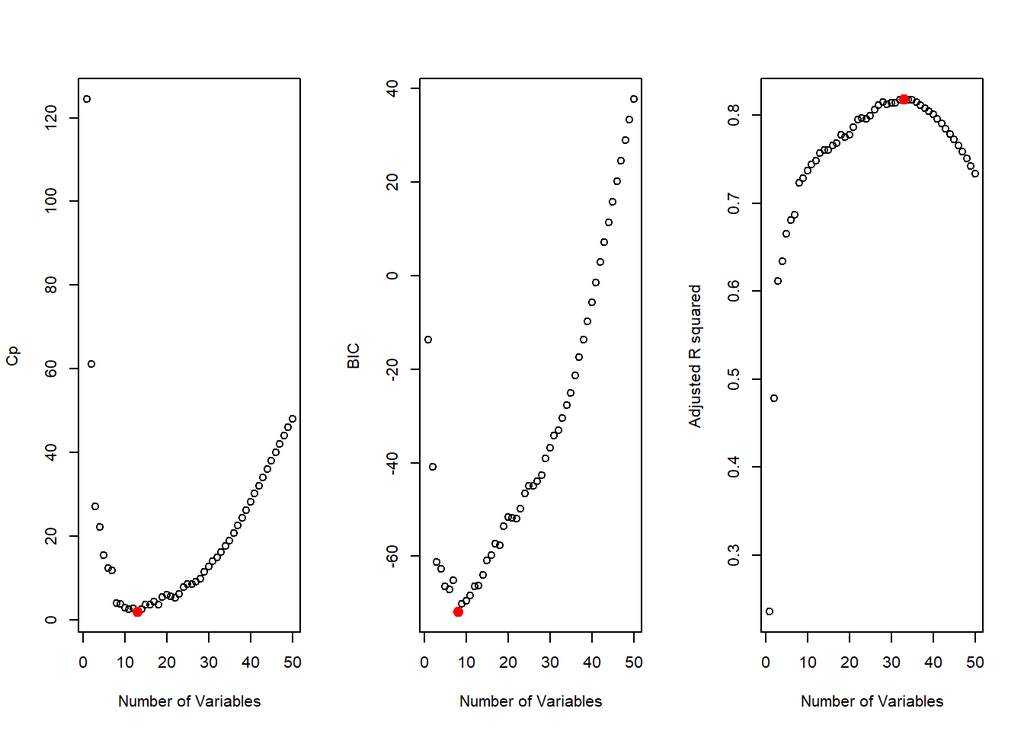

Cp, BIC, and adjusted Rsquared are shown for the best models of each size for model_df dataset. Cp and BIC are estimates of test MSE.

Mallow Cp is decreasing first at hit its lowest around 10-13 variables.

BIC, also decreases first and at its lowest at 8 then starst increasing.

Adjusted R squared has sharp increases up until around 20 and reach its maximum around 33-34 then it starts to decline.

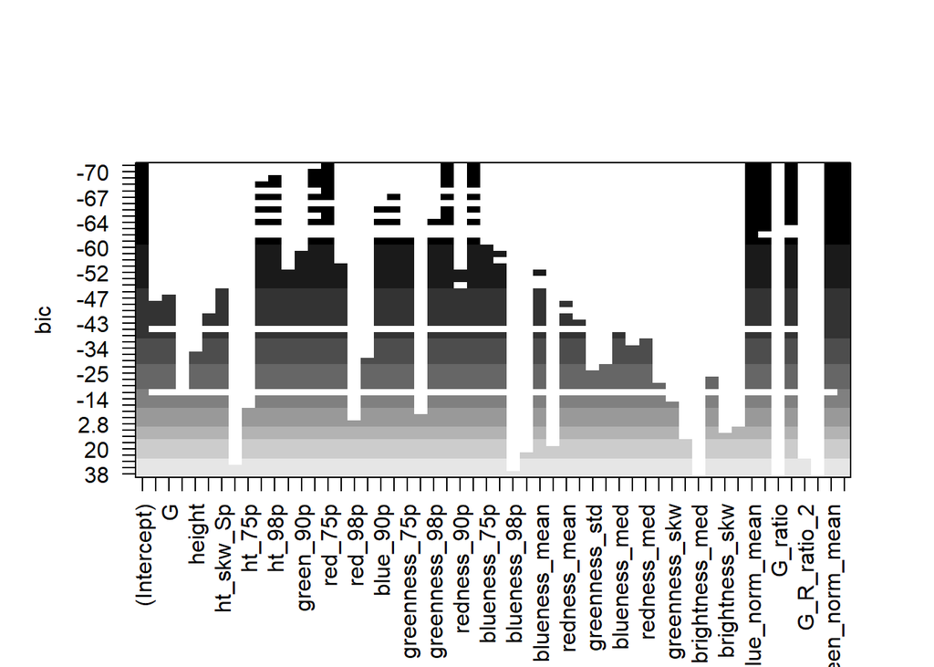

```r
plot(reg.fit.bwd) #
```

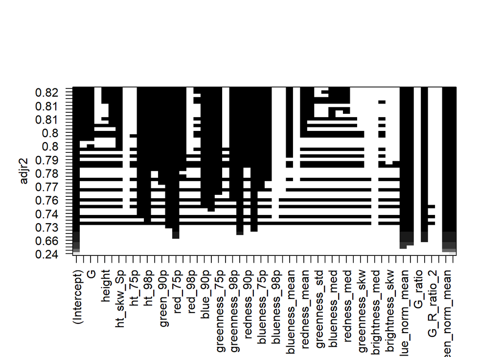

```r
plot(reg.fit.bwd, scale = "adjr2") #
```

```r
coef(reg.fit.bwd, 8)
```

```
##     (Intercept)         red_75p     redness_75p     redness_98p  blue_norm_mean
##   -1.225614e+02   -2.567474e-05    8.449926e+00   -3.660066e+00   -6.450002e+00
##         R_ratio       G_R_ratio green_norm_mean         B_ratio
##    1.556155e+02    1.190740e+01    6.161519e+01    1.225529e+02
```

```r
# coef(reg.fit.bwd, 9)
# coef(reg.fit.bwd, 10)
```

# Shrinkage Methods

Lasso uses L1 norm instead of L2 Norm. L1 will force some of the coefficient estimates to be exactly ‘0’ when lambda is large enough. Additionally, glmnet also standardizes the variables.

Accuracy Assessment for LASSO model:

| Status | Producer’s Accuracy | Omission | User’s Accuracy | Commission |
| --- | --- | --- | --- | --- |
| Alive | 0.95833333 | 0.04166667 | 0.7931034 | 0.4250000 |
| Dead | 0.625 | 0.375 | 0.90909091 | 0.09090909 |

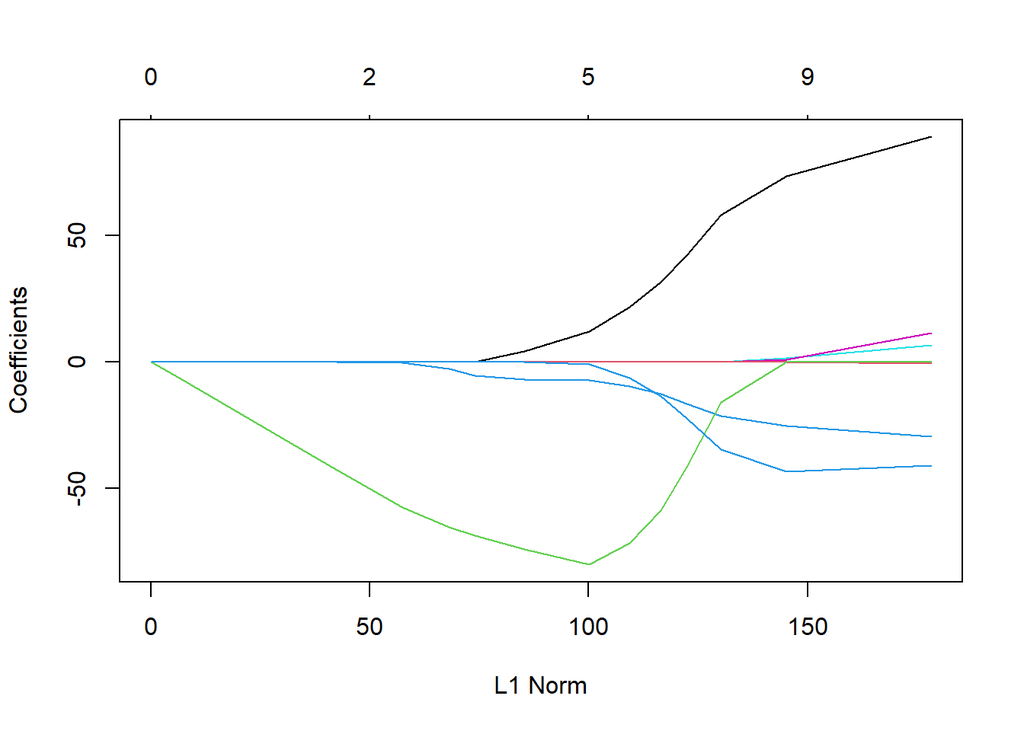

```r
grid = 10^seq(10,-2, length=100) # grid value ranging 10^10 to 10^-2, essentially covering the full range of scenarios from null model containing only the intercept, to the least square fit.
x = model.matrix(status~.,data=model_df)[,-1] # this will transform any qualitative variables into dummy variables
y = model_df$status
set.seed(1)
train = sample(1:nrow(x), nrow(x)/2)
test = (-train)
y.test = y[test]

lasso.mod = glmnet(x[train,], y[train],alpha =1, family = "binomial",lambda=grid)
plot(lasso.mod)
```

We can see from the coefficient plot that depending on the choice of tuning parameter, some of the coefficients will be exactly equal to 0. We now perform cross - validation and compute the associated test error:

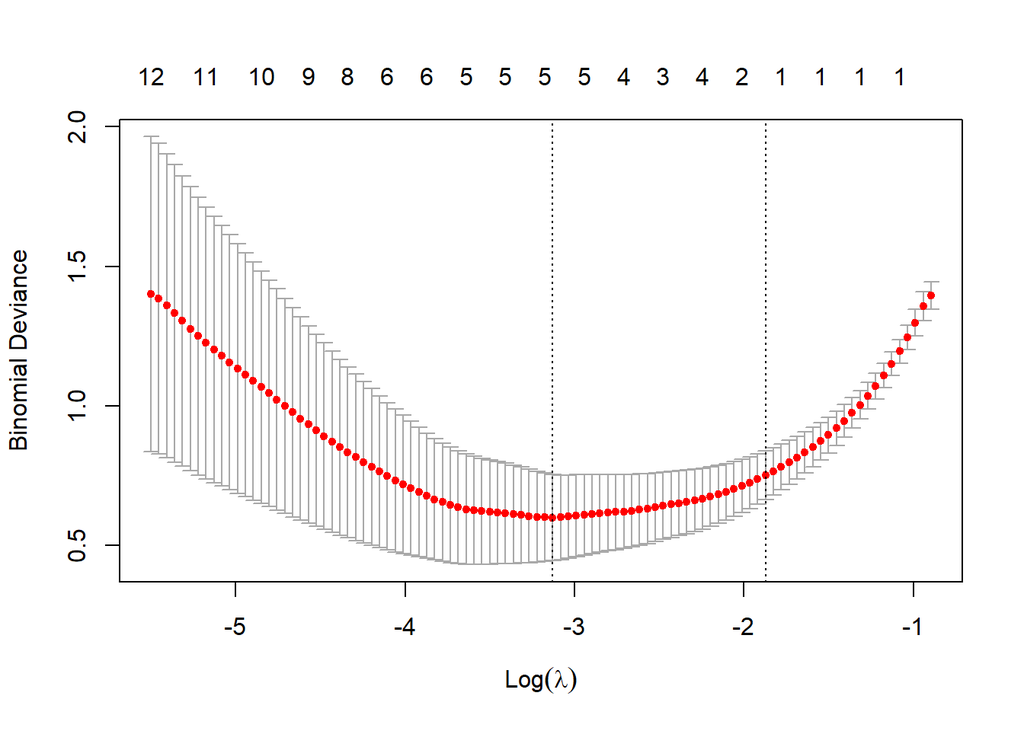

```r
model_df <- model_df %>%
  filter(status != "G") %>%
  mutate(status = factor(status))

# Perform 10 fold validation and find the optimum lambda & Classification performance on test data
set.seed(1)
cfit = cv.glmnet(x[train,],y[train],family = "binomial",alpha = 1)

plot(cfit)
```

```r
bestlam = cfit$lambda.min

# lasso.pred = predict(lasso.mod, s=bestlam, newx= x[test,])

cnf <- confusion.glmnet(cfit, newx = x[test, ], newy = y[test])
print(cnf)
```

```
##          True
## Predicted  A  D Total
##     A     23  6    29
##     D      1 10    11
##     Total 24 16    40
##
##  Percent Correct:  0.825
```

```r
c("A Producer's Accuracy"=cnf[1,1]/sum(cnf[,1]),"A Omission"=1-(cnf[1,1]/sum(cnf[,1]))) # 95.83% (4.16667%)
```

```
## A Producer's Accuracy            A Omission
##            0.95833333            0.04166667
```

```r
c("D Producer's Accuracy"=cnf[2,2]/sum(cnf[,2]),"D Omission"=1-(cnf[2,2]/sum(cnf[,2]))) # 62.5% (37.5%)
```

```
## D Producer's Accuracy            D Omission
##                 0.625                 0.375
```

```r
c("A User's Accuracy"=cnf[1,1]/sum(cnf[1,]),"A Commission"=1-(cnf[1,1]/sum(cnf))) # 79.3% (42.5%)
```

```
## A User's Accuracy      A Commission
##         0.7931034         0.4250000
```

```r
c("D User's Accuracy"=cnf[2,2]/sum(cnf[2,]),"D Commission"=1-(cnf[2,2]/sum(cnf[2,]))) # 0.91% (9%)
```

```
## D User's Accuracy      D Commission
##        0.90909091        0.09090909
```

```r
TruN <- cnf[1,1] # correct alive predictions
TruP <- cnf[2,2] # correct dead predictions
FalP <- cnf[2,1] # actual dead, predicted alive  #1
FalN <- cnf[1,2] # actual alive, predicted dead  #17
TotN <- cnf[1,1] + cnf[2,1] # actual total  Alive (Bottom left) #17
TotP <- cnf[1,2] + cnf[2,2]  # actual total Dead (bottom right) #7
Tot <- TotN + TotP
TotUA <-  cnf[1,1] + cnf[1,2]  #16
TotDA <-  cnf[2,1] + cnf[2,2]  #8
Accuracy <- (TruN+TruP)/Tot
Kappa <-(Tot *(TruN + TruP) - ((TotUA*TotN) + (TotDA* TotP)))/((Tot^2) - ((TotUA*TotN) + (TotDA* TotP))) # 0.9032258

Error <- (FalN+FalP)/Tot
sensitivity <- TruP/TotP # How good is our model at predicting positive - D
Specificity <- TruN/TotN # How good is our model at predicting negative - A
FalPos <- 1- Specificity # Predicting dead when it's alive rate

c("Accuracy"=Accuracy, "Error"=Error, "sensitivity"=sensitivity, "Specificity"=Specificity, "FalPos"=FalPos, "Kappa"=Kappa)
```

```
##    Accuracy       Error sensitivity Specificity      FalPos       Kappa
##  0.82500000  0.17500000  0.62500000  0.95833333  0.04166667  0.61538462
```

Fit the final model = coefficients chosen by cross validation

```r
x = model.matrix(status~.,data=model_df)[,-1] # this will transform any qualitative variables into dummy variables
y = model_df$status

out = glmnet(x,y,alpha=1,family = c("binomial"), lambda=grid)

lasso.coef = predict(out, type = "coefficients", s= bestlam)

rownames(lasso.coef)[which(lasso.coef!=0)] # lasso coefficients that kept
```

```
## [1] "(Intercept)"    "green_98p"      "greenness_std"  "blueness_med"
## [5] "brightness_skw" "G_ratio"
```

```r
# green_98p,greenness_std,blueness_med,brightness_skw,G_ratio
```

# Logistic Regression

Running Logistic Regression with variables chosen from different variable selection method

```r
fwd <- model_df%>%
  dplyr::select(status,ht_98p, green_98p, red_98p, brightness_std, red_norm_mean, G_ratio, G_R_ratio_2, green_norm_mean, B_ratio )

bwd <- model_df%>%
  dplyr::select(status,red_75p, redness_75p, redness_98p, blue_norm_mean,R_ratio, G_R_ratio,green_norm_mean, B_ratio)
Lasso <-  model_df%>%
  dplyr::select(status, green_98p, greenness_std, blueness_med, brightness_skw, G_ratio)

finaldf <- model_df%>%
  dplyr::select(status,ht_98p, green_98p, redness_75p, G_ratio, B_ratio )
```

## Logistic regression with all variables

```r
set.seed(1)
n= length(model_df$status)

Z = sample(1:nrow(model_df), 0.7*nrow(model_df))
model_df_train <- model_df[Z,]
model_df_test <- model_df[-Z,]

levels(model_df$status)
```

```
## [1] "A" "D"
```

```r
glm.fits = glm(status~ ., data = model_df_train, family = binomial)
#summary(glm.fits)
Prob=fitted.values(glm.fits)


Probability = predict(glm.fits,model_df_test, type="response")
# contrasts(model_df$status)  # contrast() function indicates that R has created a dummy variable with a 1 for "D" - Dead trees

#  extracting the fitted values from "fit"
Prob=fitted.values(glm.fits)


# We will classify "Dead trees" as having the probability that exceeds 0.5.

Predicted.Direction <- ifelse(Probability>0.5,"D","A")


model_df_conf <- table("Predicted"=Predicted.Direction,"Actual"=model_df_test$status)
model_df_conf
```

```
##          Actual
## Predicted A D
##         A 8 2
##         D 9 5
```

```r
c("A Producer's Accuracy"=model_df_conf[1,1]/sum(model_df_conf[,1]),"A Omission"=1-(model_df_conf[1,1]/sum(model_df_conf[,1]))) # 94.12% (5.88%)
```

```
## A Producer's Accuracy            A Omission
##             0.4705882             0.5294118
```

```r
c("D Producer's Accuracy"=model_df_conf[2,2]/sum(model_df_conf[,2]),"D Omission"=1-(model_df_conf[2,2]/sum(model_df_conf[,2]))) # 100% (0%)
```

```
## D Producer's Accuracy            D Omission
##             0.7142857             0.2857143
```

```r
c("A User's Accuracy"=model_df_conf[1,1]/sum(model_df_conf[1,]),"A Commission"=1-(model_df_conf[1,1]/sum(model_df_conf))) # 100% (0%)
```

```
## A User's Accuracy      A Commission
##         0.8000000         0.6666667
```

```r
c("D User's Accuracy"=model_df_conf[2,2]/sum(model_df_conf[2,]),"D Commission"=1-(model_df_conf[2,2]/sum(model_df_conf[2,]))) # 87.5% (12.5%)
```

```
## D User's Accuracy      D Commission
##         0.3571429         0.6428571
```

```r
TruN <- model_df_conf[1,1] # correct alive predictions
TruP <- model_df_conf[2,2] # correct dead predictions
FalP <- model_df_conf[2,1] # actual dead, predicted alive  #1
FalN <- model_df_conf[1,2] # actual alive, predicted dead  #17
TotN <- model_df_conf[1,1] + model_df_conf[2,1] # actual total  Alive (Bottom left) #17
TotP <- model_df_conf[1,2] + model_df_conf[2,2]  # actual total Dead (bottom right) #7
Tot <- TotN + TotP
TotUA <-  model_df_conf[1,1] + model_df_conf[1,2]  #16
TotDA <-  model_df_conf[2,1] + model_df_conf[2,2]  #8
Accuracy <- (TruN+TruP)/Tot
Kappa <-(Tot *(TruN + TruP) - ((TotUA*TotN) + (TotDA* TotP)))/((Tot^2) - ((TotUA*TotN) + (TotDA* TotP))) # 0.9032258

Error <- (FalN+FalP)/Tot
sensitivity <- TruP/TotP # How good is our model at predicting positive - D
Specificity <- TruN/TotN # How good is our model at predicting negative - A
FalPos <- 1- Specificity # Predicting dead when it's alive rate

c("Accuracy"=Accuracy, "Error"=Error, "sensitivity"=sensitivity, "Specificity"=Specificity, "FalPos"=FalPos, "Kappa"=Kappa)
```

```
##    Accuracy       Error sensitivity Specificity      FalPos       Kappa
##   0.5416667   0.4583333   0.7142857   0.4705882   0.5294118   0.1428571
```

## Logistic regression with FWD selected variables

Deviance Residual look good since they are close to being centered on 0 and are roughly symmetrical.

| model | Accuracy | Kappa |
| --- | --- | --- |
| forward | 0.95833333 | 0.90322581 |
| backward | 0.8750000 | 0.7096774 |

Accuracy Assessment for fwd_glm model (best glm):

[output not shown]

```r
set.seed(1)
n= length(fwd$status)

Z = sample(1:nrow(fwd), 0.7*nrow(fwd))
fwd_train <- fwd[Z,]
fwd_test <- fwd[-Z,]

levels(fwd$status)
```

```
## [1] "A" "D"
```

```r
glm.fits = glm(status~ ., data = fwd_train, family = binomial)
summary(glm.fits)
```

```
##
## Call:
## glm(formula = status ~ ., family = binomial, data = fwd_train)
##
## Deviance Residuals:
##      Min        1Q    Median        3Q       Max
## -1.77118  -0.34771  -0.08786   0.45109   2.32325
##
## Coefficients:
##                   Estimate Std. Error z value Pr(>|z|)
## (Intercept)      7.912e+02  6.686e+02   1.183    0.237
## ht_98p           2.387e-03  1.140e-01   0.021    0.983
## green_98p       -4.100e-04  3.604e-04  -1.138    0.255
## red_98p          3.011e-04  3.185e-04   0.946    0.344
## brightness_std   3.939e-05  1.409e-04   0.280    0.780
## red_norm_mean   -1.536e+02  2.820e+02  -0.545    0.586
## G_ratio         -1.438e+03  1.089e+03  -1.320    0.187
## G_R_ratio_2      4.221e+02  3.912e+02   1.079    0.281
## green_norm_mean  1.521e+01  3.196e+02   0.048    0.962
## B_ratio         -7.834e+02  7.009e+02  -1.118    0.264
##
## (Dispersion parameter for binomial family taken to be 1)
##
##     Null deviance: 77.347  on 55  degrees of freedom
## Residual deviance: 35.347  on 46  degrees of freedom
## AIC: 55.347
##
## Number of Fisher Scoring iterations: 6
```

```r
Prob=fitted.values(glm.fits)
summary(Prob)
```

```
##     Min.  1st Qu.   Median     Mean  3rd Qu.     Max.
## 0.002191 0.050584 0.449682 0.464286 0.878951 0.974316
```

```r
Probability = predict(glm.fits,fwd_test, type="response")

# contrasts(fwd$status)  # contrast() function indicates that R has created a dummy variable with a 1 for "D" - Dead trees

#  extracting the fitted values from "fit"
Prob=fitted.values(glm.fits)
summary(Prob)
```

```
##     Min.  1st Qu.   Median     Mean  3rd Qu.     Max.
## 0.002191 0.050584 0.449682 0.464286 0.878951 0.974316
```

```r
# We will classify "Dead trees" as having the probability that exceeds 0.5.

Predicted.Direction <- ifelse(Probability>0.5,"D","A")


fwd_conf <- table("Predicted"=Predicted.Direction,"Actual"=fwd_test$status)
fwd_conf
```

```
##          Actual
## Predicted  A  D
##         A 16  0
##         D  1  7
```

```r
c("A Producer's Accuracy"=fwd_conf[1,1]/sum(fwd_conf[,1]),"A Omission"=1-(fwd_conf[1,1]/sum(fwd_conf[,1]))) # 94.12% (5.88%)
```

```
## A Producer's Accuracy            A Omission
##            0.94117647            0.05882353
```

```r
c("D Producer's Accuracy"=fwd_conf[2,2]/sum(fwd_conf[,2]),"D Omission"=1-(fwd_conf[2,2]/sum(fwd_conf[,2]))) # 100% (0%)
```

```
## D Producer's Accuracy            D Omission
##                     1                     0
```

```r
c("A User's Accuracy"=fwd_conf[1,1]/sum(fwd_conf[1,]),"A Commission"=1-(fwd_conf[1,1]/sum(fwd_conf))) # 100% (0%)
```

```
## A User's Accuracy      A Commission
##         1.0000000         0.3333333
```

```r
c("D User's Accuracy"=fwd_conf[2,2]/sum(fwd_conf[2,]),"D Commission"=1-(fwd_conf[2,2]/sum(fwd_conf[2,]))) # 87.5% (12.5%)
```

```
## D User's Accuracy      D Commission
##             0.875             0.125
```

```r
TruN <- fwd_conf[1,1] # correct alive predictions
TruP <- fwd_conf[2,2] # correct dead predictions
FalP <- fwd_conf[2,1] # actual dead, predicted alive  #1
FalN <- fwd_conf[1,2] # actual alive, predicted dead  #17
TotN <- fwd_conf[1,1] + fwd_conf[2,1] # actual total  Alive (Bottom left) #17
TotP <- fwd_conf[1,2] + fwd_conf[2,2]  # actual total Dead (bottom right) #7
Tot <- TotN + TotP
TotUA <-  fwd_conf[1,1] + fwd_conf[1,2]  #16
TotDA <-  fwd_conf[2,1] + fwd_conf[2,2]  #8
Accuracy <- (TruN+TruP)/Tot
Kappa <-(Tot *(TruN + TruP) - ((TotUA*TotN) + (TotDA* TotP)))/((Tot^2) - ((TotUA*TotN) + (TotDA* TotP))) # 0.9032258

Error <- (FalN+FalP)/Tot
sensitivity <- TruP/TotP # How good is our model at predicting positive - D
Specificity <- TruN/TotN # How good is our model at predicting negative - A
FalPos <- 1- Specificity # Predicting dead when it's alive rate

c("Accuracy"=Accuracy, "Error"=Error, "sensitivity"=sensitivity, "Specificity"=Specificity, "FalPos"=FalPos, "Kappa"=Kappa)
```

```
##    Accuracy       Error sensitivity Specificity      FalPos       Kappa
##  0.95833333  0.04166667  1.00000000  0.94117647  0.05882353  0.90322581
```

```r
ll.null <- glm.fits$null.deviance/-2
ll.proposed <- glm.fits$deviance/-2

(ll.null - ll.proposed) / ll.null  # Rsquared = 0.54
```

```
## [1] 0.5430095
```

## Logistic regression with BWD selected variables

Accuracy Assessment for bwd_glm model:

| Status | Producer’s Accuracy | Omission | User’s Accuracy | Commission |
| --- | --- | --- | --- | --- |
| Alive | 0.8823529 | 0.1176471 | 0.9375 | 0.3750 |
| Dead | 0.8571429 | 0.1428571 | 0.75 | 0.25 |

```r
set.seed(1)
n= length(bwd$status)

Z = sample(1:nrow(bwd), 0.7*nrow(bwd))
bwd_train <- bwd[Z,]
bwd_test <- bwd[-Z,]


glm.fits = glm(status~ ., data = bwd_train, family = binomial)
summary(glm.fits)
```

```
##
## Call:
## glm(formula = status ~ ., family = binomial, data = bwd_train)
##
## Deviance Residuals:
##      Min        1Q    Median        3Q       Max
## -1.88946  -0.10778  -0.01616   0.16256   2.27107
##
## Coefficients:
##                   Estimate Std. Error z value Pr(>|z|)
## (Intercept)     -1.495e+03  7.256e+02  -2.060   0.0394 *
## red_75p         -2.596e-04  2.026e-04  -1.282   0.2000
## redness_75p      1.015e+02  6.619e+01   1.534   0.1251
## redness_98p     -3.860e+01  2.603e+01  -1.483   0.1380
## blue_norm_mean   6.009e+02  5.008e+02   1.200   0.2302
## R_ratio          1.836e+03  8.493e+02   2.161   0.0307 *
## G_R_ratio        1.364e+02  5.449e+01   2.503   0.0123 *
## green_norm_mean  7.888e+02  5.154e+02   1.530   0.1259
## B_ratio          7.901e+02  6.204e+02   1.274   0.2028
## ---
## Signif. codes:  0 '***' 0.001 '**' 0.01 '*' 0.05 '.' 0.1 ' ' 1
##
## (Dispersion parameter for binomial family taken to be 1)
##
##     Null deviance: 77.347  on 55  degrees of freedom
## Residual deviance: 21.457  on 47  degrees of freedom
## AIC: 39.457
##
## Number of Fisher Scoring iterations: 8
```

```r
Probability = predict(glm.fits,bwd_test, type="response")

# contrasts(bwd$status)  # contrast() function indicates that R has created a dummy variable with a 1 for "D" - Dead trees


Predicted.Direction <- ifelse(Probability>0.5,"D","A")
Predicted.Direction
```

```
##   3   5   9  12  15  19  26  27  29  30  31  41  50  55  58  61  65  67  70  72
## "D" "A" "A" "D" "D" "D" "A" "A" "A" "A" "A" "D" "A" "D" "A" "A" "A" "A" "A" "A"
##  73  74  76  80
## "D" "A" "D" "A"
```

```r
bwd_conf <- table("Predicted"=Predicted.Direction,"Actual"=bwd_test$status)
bwd_conf
```

```
##          Actual
## Predicted  A  D
##         A 15  1
##         D  2  6
```

```r
c("A Producer's Accuracy"=bwd_conf[1,1]/sum(bwd_conf[,1]),"A Omission"=1-(bwd_conf[1,1]/sum(bwd_conf[,1]))) # 88.23% (0.1176%)
```

```
## A Producer's Accuracy            A Omission
##             0.8823529             0.1176471
```

```r
c("D Producer's Accuracy"=bwd_conf[2,2]/sum(bwd_conf[,2]),"D Omission"=1-(bwd_conf[2,2]/sum(bwd_conf[,2]))) # 85.714% (0.1428%)
```

```
## D Producer's Accuracy            D Omission
##             0.8571429             0.1428571
```

```r
c("A User's Accuracy"=bwd_conf[1,1]/sum(bwd_conf[1,]),"A Commission"=1-(bwd_conf[1,1]/sum(bwd_conf))) # 93.75% (0.3750%)
```

```
## A User's Accuracy      A Commission
##            0.9375            0.3750
```

```r
c("D User's Accuracy"=bwd_conf[2,2]/sum(bwd_conf[2,]),"D Commission"=1-(bwd_conf[2,2]/sum(bwd_conf[2,]))) # 75% (25%)
```

```
## D User's Accuracy      D Commission
##              0.75              0.25
```

```r
TruN <- bwd_conf[1,1] # correct alive predictions
TruP <- bwd_conf[2,2] # correct dead predictions
FalP <- bwd_conf[2,1] # actual dead, predicted alive
FalN <- bwd_conf[1,2] # actual alive, predicted dead
TotN <- bwd_conf[1,1] + bwd_conf[2,1] # actual total  Alive
TotP <- bwd_conf[1,2] + bwd_conf[2,2]  # actual total Dead
Tot <- TotN + TotP

TotUA <-  bwd_conf[1,1] + bwd_conf[1,2]
TotDA <-  bwd_conf[2,1] + bwd_conf[2,2]

Kappa <-(Tot *(TruN + TruP) - ((TotUA*TotN) + (TotDA* TotP)))/((Tot^2) - ((TotUA*TotN) + (TotDA* TotP))) # 70.96

Accuracy <- (TruN+TruP)/Tot
Error <- (FalN+FalP)/Tot
sensitivity <- TruP/TotP # How good is our model at predicting positive - D
Specificity <- TruN/TotN # How good is our model at predicting negative - A
FalPos <- 1- Specificity # Predicting as dead when its alive (classifying incorrectly)

c("Accuracy"=Accuracy, "Error"=Error, "sensitivity"=sensitivity, "Specificity"=Specificity, "FalPos"=FalPos,"Kappa"=Kappa)
```

```
##    Accuracy       Error sensitivity Specificity      FalPos       Kappa
##   0.8750000   0.1250000   0.8571429   0.8823529   0.1176471   0.7096774
```

```r
ll.null <- glm.fits$null.deviance/-2
ll.proposed <- glm.fits$deviance/-2

(ll.null - ll.proposed) / ll.null  # Rsquared = 0.72
```

```
## [1] 0.7225804
```

## Logistic regression with Lasso selected variables

```r
set.seed(1)
n= length(Lasso$status)

Z = sample(1:nrow(Lasso), 0.7*nrow(Lasso))
Lasso_train <- Lasso[Z,]
Lasso_test <- Lasso[-Z,]


glm.fits = glm(status~ ., data = Lasso_train, family = binomial)
summary(glm.fits)
```

```
##
## Call:
## glm(formula = status ~ ., family = binomial, data = Lasso_train)
##
## Deviance Residuals:
##      Min        1Q    Median        3Q       Max
## -2.54024  -0.47818  -0.07339   0.37094   2.23097
##
## Coefficients:
##                  Estimate Std. Error z value Pr(>|z|)
## (Intercept)     2.205e+01  1.438e+01   1.533   0.1252
## green_98p      -8.678e-05  6.553e-05  -1.324   0.1854
## greenness_std   4.167e+01  2.697e+01   1.545   0.1224
## blueness_med    2.786e+01  1.694e+01   1.645   0.1000 .
## brightness_skw -2.061e+00  1.001e+00  -2.059   0.0395 *
## G_ratio        -4.229e+01  3.909e+01  -1.082   0.2793
## ---
## Signif. codes:  0 '***' 0.001 '**' 0.01 '*' 0.05 '.' 0.1 ' ' 1
##
## (Dispersion parameter for binomial family taken to be 1)
##
##     Null deviance: 77.347  on 55  degrees of freedom
## Residual deviance: 32.348  on 50  degrees of freedom
## AIC: 44.348
##
## Number of Fisher Scoring iterations: 6
```

```r
Probability = predict(glm.fits,Lasso_test, type="response")

# contrasts(Lasso$status)  # contrast() function indicates that R has created a dummy variable with a 1 for "D" - Dead trees


Predicted.Direction <- ifelse(Probability>0.5,"D","A")
Predicted.Direction
```

```
##   3   5   9  12  15  19  26  27  29  30  31  41  50  55  58  61  65  67  70  72
## "D" "A" "A" "D" "D" "D" "A" "A" "A" "A" "A" "A" "A" "A" "A" "A" "A" "A" "A" "D"
##  73  74  76  80
## "D" "A" "D" "A"
```

```r
Lasso_conf <- table("Predicted"=Predicted.Direction,"Actual"=Lasso_test$status)
Lasso_conf
```

```
##          Actual
## Predicted  A  D
##         A 16  1
##         D  1  6
```

```r
TruN <- Lasso_conf[1,1] # correct alive predictions
TruP <- Lasso_conf[2,2] # correct dead predictions
FalP <- Lasso_conf[2,1] # actual dead, predicted alive
FalN <- Lasso_conf[1,2] # actual alive, predicted dead
TotN <- Lasso_conf[1,1] + Lasso_conf[2,1] # actual total  Alive
TotP <- Lasso_conf[1,2] + Lasso_conf[2,2]  # actual total Dead
Tot <- TotN + TotP

TotUA <-  Lasso_conf[1,1] + Lasso_conf[1,2]
TotDA <-  Lasso_conf[2,1] + Lasso_conf[2,2]

Kappa <-(Tot *(TruN + TruP) - ((TotUA*TotN) + (TotDA* TotP)))/((Tot^2) - ((TotUA*TotN) + (TotDA* TotP))) # 79.83

Accuracy <- (TruN+TruP)/Tot
Error <- (FalN+FalP)/Tot
sensitivity <- TruP/TotP # How good is our model at predicting positive - D
Specificity <- TruN/TotN # How good is our model at predicting negative - A
FalPos <- 1- Specificity # Predicting as dead when its alive

c("Accuracy"=Accuracy, "Error"=Error, "sensitivity"=sensitivity, "Specificity"=Specificity, "FalPos"=FalPos, "Kappa"=Kappa)
```

```
##    Accuracy       Error sensitivity Specificity      FalPos       Kappa
##  0.91666667  0.08333333  0.85714286  0.94117647  0.05882353  0.79831933
```

```r
ll.null <- glm.fits$null.deviance/-2
ll.proposed <- glm.fits$deviance/-2

(ll.null - ll.proposed) / ll.null  # Rsquared = 0.58
```

```
## [1] 0.5817775
```

## Logistic regression with team picked variables from all 3 models

```r
set.seed(1)
n= length(finaldf$status)

Z = sample(1:nrow(finaldf), 0.7*nrow(finaldf))
finaldf_train <- finaldf[Z,]
finaldf_test <- finaldf[-Z,]


glm.fits = glm(status~ ., data = finaldf_train, family = binomial)
summary(glm.fits)
```

```
##
## Call:
## glm(formula = status ~ ., family = binomial, data = finaldf_train)
##
## Deviance Residuals:
##     Min       1Q   Median       3Q      Max
## -2.0024  -0.3928  -0.1456   0.5032   2.5842
##
## Coefficients:
##               Estimate Std. Error z value Pr(>|z|)
## (Intercept) -2.261e+01  3.981e+01  -0.568   0.5700
## ht_98p       2.252e-03  1.039e-01   0.022   0.9827
## green_98p   -1.363e-04  7.582e-05  -1.797   0.0723 .
## redness_75p  3.583e+01  2.243e+01   1.598   0.1101
## G_ratio     -4.039e+01  5.046e+01  -0.800   0.4235
## B_ratio      8.680e+01  4.760e+01   1.823   0.0683 .
## ---
## Signif. codes:  0 '***' 0.001 '**' 0.01 '*' 0.05 '.' 0.1 ' ' 1
##
## (Dispersion parameter for binomial family taken to be 1)
##
##     Null deviance: 77.347  on 55  degrees of freedom
## Residual deviance: 36.668  on 50  degrees of freedom
## AIC: 48.668
##
## Number of Fisher Scoring iterations: 6
```

```r
Probability = predict(glm.fits,finaldf_test, type="response")

# contrasts(finaldf$status)  # contrast() function indicates that R has created a dummy variable with a 1 for "D" - Dead trees


Predicted.Direction <- ifelse(Probability>0.5,"D","A")


finaldf_conf <- table("Predicted"=Predicted.Direction,"Actual"=finaldf_test$status)
finaldf_conf
```

```
##          Actual
## Predicted  A  D
##         A 15  0
##         D  2  7
```

```r
TruN <- finaldf_conf[1,1] # correct alive predictions
TruP <- finaldf_conf[2,2] # correct dead predictions
FalP <- finaldf_conf[2,1] # actual dead, predicted alive
FalN <- finaldf_conf[1,2] # actual alive, predicted dead
TotN <- finaldf_conf[1,1] + finaldf_conf[2,1] # actual total  Alive
TotP <- finaldf_conf[1,2] + finaldf_conf[2,2]  # actual total Dead
Tot <- TotN + TotP
TotUA <-  finaldf_conf[1,1] + finaldf_conf[1,2]
TotDA <-  finaldf_conf[2,1] + finaldf_conf[2,2]

Kappa <-(Tot *(TruN + TruP) - ((TotUA*TotN) + (TotDA* TotP)))/((Tot^2) - ((TotUA*TotN) + (TotDA* TotP)))

Accuracy <- (TruN+TruP)/Tot
Error <- (FalN+FalP)/Tot
sensitivity <- TruP/TotP # How good is our model at predicting positive - D
Specificity <- TruN/TotN # How good is our model at predicting negative - A
FalPos <- 1- Specificity # Predicting as dead when its alive

c("Accuracy"=Accuracy, "Error"=Error, "sensitivity"=sensitivity, "Specificity"=Specificity, "FalPos"=FalPos, "Kappa"=Kappa)
```

```
##    Accuracy       Error sensitivity Specificity      FalPos       Kappa
##  0.91666667  0.08333333  1.00000000  0.88235294  0.11764706  0.81395349
```

```r
ll.null <- glm.fits$null.deviance/-2
ll.proposed <- glm.fits$deviance/-2

(ll.null - ll.proposed) / ll.null  # Rsquared = 0.52/
```

```
## [1] 0.5259201
```

# Nonparametric Models

## Classification tree

```r
class.tree <- tree(status ~., data=fwd, mindev=0.005)

summary(class.tree) # summary function here lists the variables that are used as internal nodes in the tree, the number of terminal nodes, and the training error rate
```

```
##
## Classification tree:
## tree(formula = status ~ ., data = fwd, mindev = 0.005)
## Variables actually used in tree construction:
## [1] "G_ratio"         "green_norm_mean" "ht_98p"          "green_98p"
## Number of terminal nodes:  7
## Residual mean deviance:  0.3394 = 24.78 / 73
## Misclassification error rate: 0.075 = 6 / 80
```

We see that the training error rate is 7.5%. A small deviance indicates a tree that provides a good fit to the training data.

One of the most attractive properties of trees is that they can be graphically displayed.

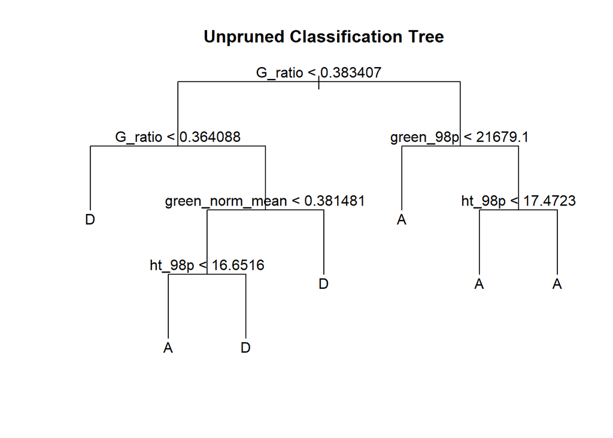

```r
plot(class.tree,type ="uniform")
text(class.tree, pretty=0)
title(main = "Unpruned Classification Tree")
```

In order to properly evaluate the performance of a classification tree on these data, we must estimate the test error rather than simply computing the training error.

```r
# estimate the correct classification rate by cross validation.

set.seed(1)

n= length(fwd$status)

Z = sample(1:nrow(fwd), 0.7*nrow(fwd))

train.tree = tree(status ~ .,data=fwd[Z,])


status.predict = predict(train.tree,fwd, type = "class")

# test confusion
table(status.predict[-Z], fwd$status[-Z])
```

```
##
##      A  D
##   A 15  1
##   D  2  6
```

```r
accuracy = function(actual, predicted) {
  mean(actual == predicted)
}

# train accuracy
# accuracy(predicted = status.predict[Z], actual = fwd$status[Z])

# test accuracy
accuracy(predicted = status.predict[-Z], actual = fwd$status[-Z])  # 0.875
```

```
## [1] 0.875
```

We will now use cross-validation to find a tree by considering trees of different sizes which have been pruned from our original tree. The function cv.tree() performs cross valiation in order to determine the optimal level of tree complexity; FUN = prune.misclass to indicated that we want the classification error rate to guide the cross-validation and pruning process rather than the default cv.tree(), which is a deviance.

```r
# Using cross validation to determine the optimal complexity of a tree and the number of terminal nodes that minimizes the deviance.

#cv = cv.tree(train.tree)
# cv
# plot(cv)

# instead of optimizing by the smallest deviance, optimize the complexity and the number of terminal nodes by the smallest mis-classification error

cv = cv.tree(train.tree, FUN = prune.misclass)
cv
```

```
## $size
## [1] 5 4 2 1
##
## $dev
## [1] 10 10 10 32
##
## $k
## [1] -Inf  0.0  0.5 20.0
##
## $method
## [1] "misclass"
##
## attr(,"class")
## [1] "prune"         "tree.sequence"
```

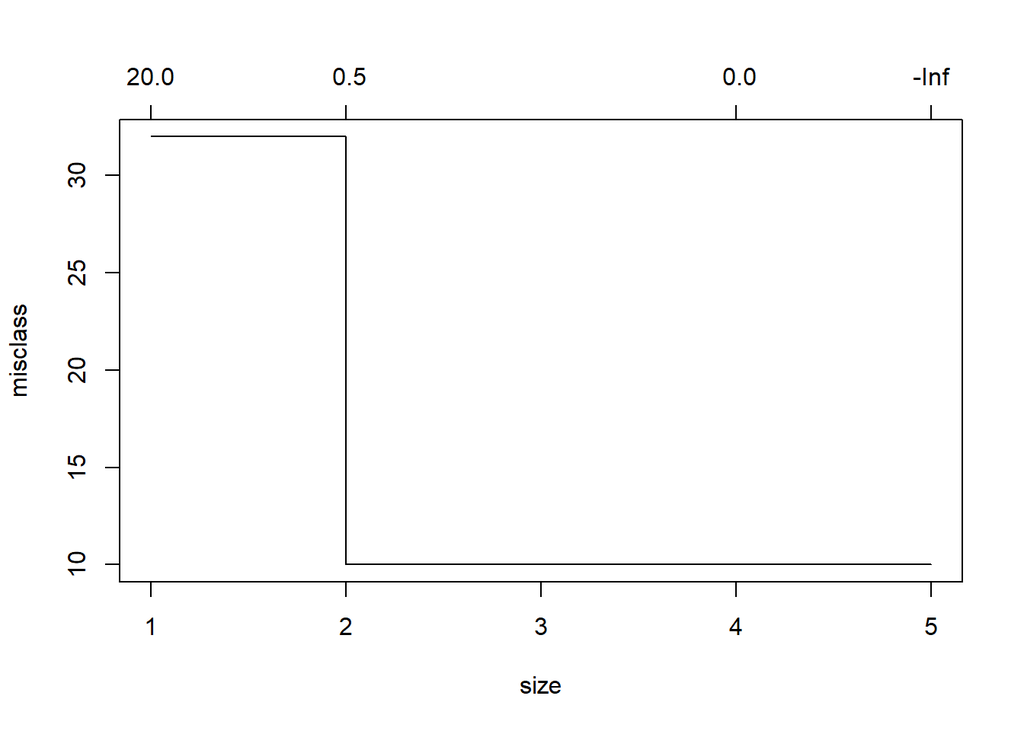

```r
plot(cv)
```

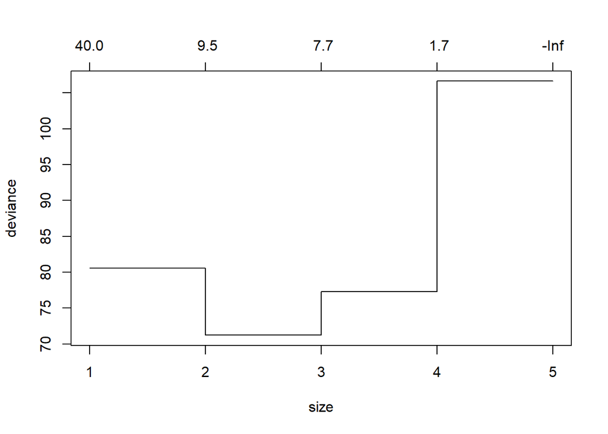

```r
cv = cv.tree(train.tree)
plot(cv)
```

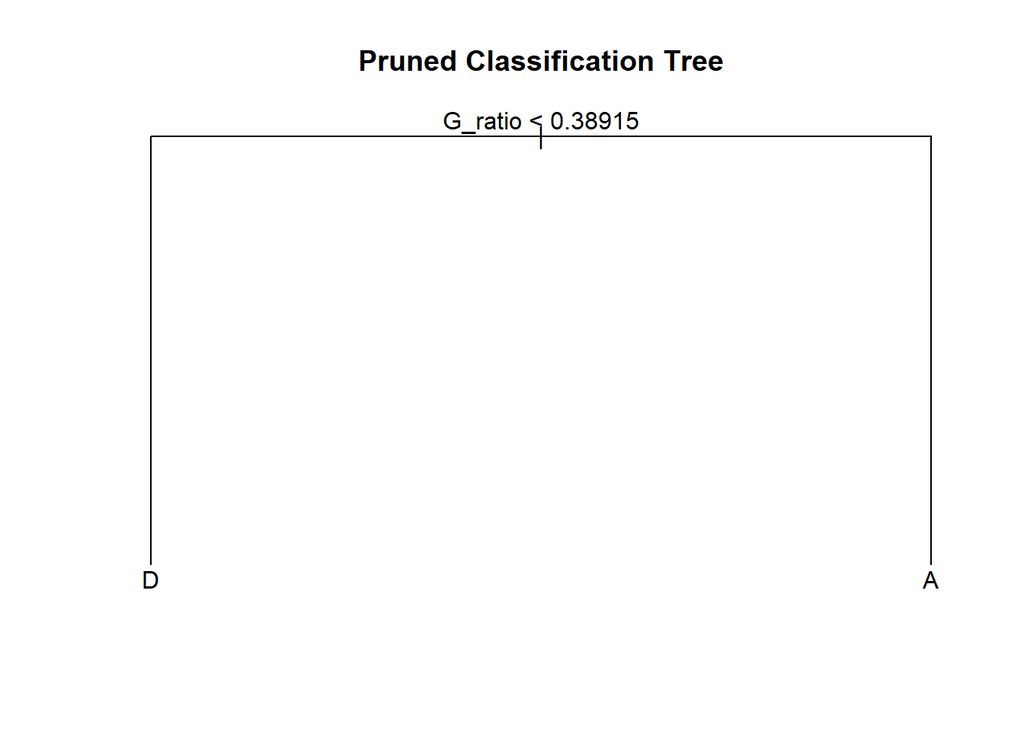

```r
#prune the tree to the optimal size which is 2 obtained above

tree.pruned = prune.misclass(train.tree, best = 2)

plot(tree.pruned)
text(tree.pruned, pretty=0)
title(main = "Pruned Classification Tree")
```

```r
# tree.pred = predict(tree.pruned,fwd[-Z])
```

## Random Forest

| model | Accuracy | Kappa |
| --- | --- | --- |
| rf_default | 0.8466667 | 0.6827506 |
| **rf_mtry** | **0.8766667** | **0.7424242** |
| rf_maxnode | 0.8366667 | 0.6655012 |
| rf_maxtrees | 0.8233333 | 0.6442890 |
| rf_fit | 0.8500000 | 0.6878788 |

However, when we ran the models against our test set, our rf_fit/final model performed the better with 95.83% accuracy and 90.32% kappa. After running our Random Forest model with various mtry, maxnode and ntree hyperparameters, we settled on 16, 7 and 450 respectively.

| model | Accuracy | Kappa |
| --- | --- | --- |
| rf_default | 0.9166667 | 0.8139535 |
| rf_mtry | 0.8750000 | 0.7096774 |
| rf_maxnode | 0.9166667 | 0.7983193 |
| rf_maxtrees | 0.9166667 | 0.7983193 |
| **rf_fit** | **0.9583333** | **0.9032258** |

Accuracy Assessment for rf_fit model:

| Status | Producer’s Accuracy | Omission | User’s Accuracy | Commission |
| --- | --- | --- | --- | --- |
| Alive | 0.94117647 | 0.05882353 | 1 | 0 |
| Dead | 1 | 0 | 0.875 | 0.125 |

Below is the table of the top 5 importance variables for our final model (rf_fit):

| Variable | Importance |
| --- | --- |
| G_ratio | 100.00 |
| greenness_90p | 64.94 |
| greenness_75p | 63.44 |
| green_norm_mean | 62.39 |
| G_R_ratio_2 | 54.20 |

```r
set.seed(1)

training <- sample(1:nrow(model_df), 0.7*nrow(model_df))
train_set <- model_df[training,]
test_set <- model_df[-training,]

set.seed(1)

# Define the control
trControl <- trainControl(method = "cv", number = 10, search = "grid")

# Run default model
rf_default <- train(status ~., data=train_set, method="rf", metric="Accuracy", trControl=trControl)
rf_default # mtry=27, Accuracy=0.8466667 and Kappa=0.6827506
```

```
## Random Forest
##
## 56 samples
## 53 predictors
##  2 classes: 'A', 'D'
##
## No pre-processing
## Resampling: Cross-Validated (10 fold)
## Summary of sample sizes: 50, 50, 51, 50, 50, 51, ...
## Resampling results across tuning parameters:
##
##   mtry  Accuracy   Kappa
##    2    0.7733333  0.5300866
##   27    0.8466667  0.6827506
##   53    0.8466667  0.6827506
##
## Accuracy was used to select the optimal model using the largest value.
## The final value used for the model was mtry = 27.
```

```r
res_rf_default <- as_tibble(rf_default$results[which.max(rf_default$results[,2]),]) %>%
  mutate(model = "rf_default") %>% as.data.frame()

rf_pred <- predict(rf_default, test_set)
rf_pred
```

```
##  [1] D A A D D D A A A A A D A A A A A A D D D A D A
## Levels: A D
```

```r
mat_rf <- confusionMatrix(rf_pred, test_set$status)$overall %>%
  t() %>%
  as.data.frame() %>%
  mutate(model = "rf_default")
mat_rf # Accuracy=0.9166667 and Kappa   0.8139535
```

```
##    Accuracy     Kappa AccuracyLower AccuracyUpper AccuracyNull AccuracyPValue
## 1 0.9166667 0.8139535     0.7300272     0.9897437    0.7083333     0.01467966
##   McnemarPValue      model
## 1     0.4795001 rf_default
```

```r
# Search best mtry
set.seed(1)

tuneGrid <- expand.grid(.mtry = c(1:53))
rf_mtry <- train(status ~., data=train_set, method="rf", metric="Accuracy", tuneGrid=tuneGrid, trControl=trControl,
                 importance=TRUE)

#rf_mtry #mtry=16, Accuracy=0.8666667 and Kappa=0.7212121

c("best_mtry" = rf_mtry$bestTune$mtry, "Accuracy" = max(rf_mtry$results$Accuracy))
```

```
##  best_mtry   Accuracy
## 16.0000000  0.8666667
```

```r
best_mtry <- rf_mtry$bestTune$mtry # 16 with accuracy of 0.8933333

tuneGrid <- expand.grid(.mtry = best_mtry)

rf_mtry <- train(status ~., data=train_set, method="rf", metric="Accuracy", tuneGrid=tuneGrid, trControl=trControl,
                 importance=TRUE)

res_rf_mtry <- as_tibble(rf_mtry$results[which.max(rf_mtry$results[,2]),]) %>%
  mutate(model = "rf_mtry") %>% as.data.frame()

rf_mtry_pred <- predict(rf_mtry, test_set)
rf_mtry_pred
```

```
##  [1] D A A D D D A A A A A D A A A A A A D A D A D A
## Levels: A D
```

```r
mat_rf_mtry <- confusionMatrix(rf_mtry_pred, test_set$status)$overall %>%
  t() %>%
  as.data.frame() %>%
  mutate(model = "rf_mtry")
mat_rf_mtry # Accuracy=0.875 and Kappa=0.7096774
```

```
##   Accuracy     Kappa AccuracyLower AccuracyUpper AccuracyNull AccuracyPValue
## 1    0.875 0.7096774     0.6763886     0.9734407    0.7083333     0.05064318
##   McnemarPValue   model
## 1             1 rf_mtry
```

```r
# Search the best maxnodes
store_maxnode <- list()
tuneGrid <- expand.grid(.mtry = best_mtry)

for (maxnodes in c(5:15)) {
  set.seed(1)
  rf_maxnode <- train(status~.,
                      data = train_set,
                      method = "rf",
                      metric = "Accuracy",
                      tuneGrid = tuneGrid,
                      trControl = trControl,
                      importance = TRUE,
                      maxnodes = maxnodes)
  current_iteration <- toString(maxnodes)
  store_maxnode[[current_iteration]] <- rf_maxnode
}
results_maxnode <- resamples(store_maxnode)
summary_maxnode <- summary(results_maxnode)

best_maxnode <- as.numeric(names(which.max(summary_maxnode$statistics$Accuracy[,4])))

rf_maxnode <- train(status ~., data=train_set, method="rf", metric="Accuracy",
                 tuneGrid = tuneGrid,
                 trControl=trControl,
                 importance=TRUE,
                 maxnodes=best_maxnode)

res_rf_maxnode <- as_tibble(rf_maxnode$results[which.max(rf_maxnode$results[,2]),]) %>%
  mutate(model = "rf_maxnode") %>% as.data.frame() # mtry=16, Accuracy=0.85 and Kappa=0.6878788

rf_maxnode_pred <- predict(rf_maxnode, test_set)
rf_maxnode_pred
```

```
##  [1] D A A D D D A A A A A D A A A A A A A A D A D A
## Levels: A D
```

```r
mat_rf_maxnode <- confusionMatrix(rf_maxnode_pred, test_set$status)$overall %>%
  t() %>%
  as.data.frame() %>%
  mutate(model = "rf_maxnode")
mat_rf_maxnode # Accuracy=0.9166667 and Kappa=0.7983193
```

```
##    Accuracy     Kappa AccuracyLower AccuracyUpper AccuracyNull AccuracyPValue
## 1 0.9166667 0.7983193     0.7300272     0.9897437    0.7083333     0.01467966
##   McnemarPValue      model
## 1             1 rf_maxnode
```

```r
# Search for best ntrees
store_maxtrees <- list()

for (ntree in c(250, 300, 350, 400, 450, 500, 550, 600, 800, 1000, 2000)) {
  set.seed(1)
  rf_maxtrees <- train(status~.,
                       data = train_set,
                       method = "rf",
                       metric = "Accuracy",
                       tuneGrid = tuneGrid,
                       trControl = trControl,
                       importance = TRUE,
                       maxnodes = best_maxnode,
                       ntree = ntree)
  key <- toString(ntree)
  store_maxtrees[[key]] <- rf_maxtrees
}
results_tree <- resamples(store_maxtrees)
summary_ntree <- summary(results_tree)

best_ntree <- as.numeric(names(which.max(summary_ntree$statistics$Accuracy[,4])))

rf_maxtrees <- train(status ~., data=train_set, method="rf", metric="Accuracy",
                 tuneGrid = tuneGrid,
                 trControl=trControl,
                 importance=TRUE,
                 maxnodes=best_maxnode,
                 ntree=best_ntree)

res_rf_maxtrees <- as_tibble(rf_maxtrees$results[which.max(rf_maxtrees$results[,2]),]) %>%
  mutate(model = "rf_maxtrees") %>% as.data.frame() # mtry=16, Accuracy=0.85 and Kappa=0.6878788

rf_maxtrees_pred <- predict(rf_maxtrees, test_set)
rf_maxtrees_pred
```

```
##  [1] D A A D D D A A A A A D A A A A A A A A D A D A
## Levels: A D
```

```r
mat_rf_maxtrees <- confusionMatrix(rf_maxtrees_pred, test_set$status)$overall %>%
  t() %>%
  as.data.frame() %>%
  mutate(model = "rf_maxtrees")
mat_rf_maxtrees # Accuracy=0.9166667 and Kappa=0.7983193
```

```
##    Accuracy     Kappa AccuracyLower AccuracyUpper AccuracyNull AccuracyPValue
## 1 0.9166667 0.7983193     0.7300272     0.9897437    0.7083333     0.01467966
##   McnemarPValue       model
## 1             1 rf_maxtrees
```

```r
# Using the above model
set.seed(1)

rf_fit <- train(status~.,
                train_set,
                method = "rf",
                metric = "Accuracy",
                tuneGrid = tuneGrid,
                trControl = trControl,
                maxnodes = best_maxnode,
                ntree = best_ntree,
                importance = TRUE)

rf_fit # Accuracy=0.85 and Kappa=0.6878788
```

```
## Random Forest
##
## 56 samples
## 53 predictors
##  2 classes: 'A', 'D'
##
## No pre-processing
## Resampling: Cross-Validated (10 fold)
## Summary of sample sizes: 50, 50, 51, 50, 50, 51, ...
## Resampling results:
##
##   Accuracy  Kappa
##   0.85      0.6878788
##
## Tuning parameter 'mtry' was held constant at a value of 16
```

```r
# Evaluate the model
res_rf_fit <- as_tibble(rf_fit$results[which.max(rf_fit$results[,2]),]) %>%
  mutate(model = "rf_fit") %>% as.data.frame() # mtry=16, Accuracy=0.85 and Kappa=0.6878788

rf_fit_pred <- predict(rf_fit, test_set)
rf_fit_pred
```

```
##  [1] D A A D D D A A A A A D A A A A A A A D D A D A
## Levels: A D
```

```r
mat_rf_fit <- confusionMatrix(rf_fit_pred, test_set$status)$overall %>%
  t() %>%
  as.data.frame() %>%
  mutate(model = "rf_fit")
mat_rf_fit # Accuracy=0.9583333 and Kappa=0.9032258
```

```
##    Accuracy     Kappa AccuracyLower AccuracyUpper AccuracyNull AccuracyPValue
## 1 0.9583333 0.9032258     0.7887983     0.9989456    0.7083333    0.002769664
##   McnemarPValue  model
## 1             1 rf_fit
```

```r
conf_rf_fit <- confusionMatrix(table(rf_fit_pred, test_set$status))$table
conf_rf_fit
```

```
##
## rf_fit_pred  A  D
##           A 16  0
##           D  1  7
```

```r
c("A Producer's Accuracy"=conf_rf_fit[1,1]/sum(conf_rf_fit[,1]),"A Omission"=1-(conf_rf_fit[1,1]/sum(conf_rf_fit[,1]))) # 94.12% (5.88%)
```

```
## A Producer's Accuracy            A Omission
##            0.94117647            0.05882353
```

```r
c("D Producer's Accuracy"=conf_rf_fit[2,2]/sum(conf_rf_fit[,2]),"D Omission"=1-(conf_rf_fit[2,2]/sum(conf_rf_fit[,2]))) # 100% (0%)
```

```
## D Producer's Accuracy            D Omission
##                     1                     0
```

```r
c("A User's Accuracy"=conf_rf_fit[1,1]/sum(conf_rf_fit[1,]),"A Commission"=1-(conf_rf_fit[1,1]/sum(conf_rf_fit[1,]))) # 100% (0%)
```

```
## A User's Accuracy      A Commission
##                 1                 0
```

```r
c("D User's Accuracy"=conf_rf_fit[2,2]/sum(conf_rf_fit[2,]),"D Commission"=1-(conf_rf_fit[2,2]/sum(conf_rf_fit[2,]))) # 87.5% (12.5%)
```

```
## D User's Accuracy      D Commission
##             0.875             0.125
```

```r
var_imp <- varImp(rf_fit)
var_imp # Top 5 variables need to be explained
```

```
## rf variable importance
##
##   only 20 most important variables shown (out of 53)
##
##                 Importance
## G_ratio             100.00
## greenness_90p        64.94
## greenness_75p        63.44
## green_norm_mean      62.39
## G_R_ratio_2          54.20
## blueness_mean        53.91
## G_R_ratio            51.61
## blueness_med         46.26
## greenness_98p        42.24
## height               37.23
## ht_90p               35.46
## red_98p              35.08
## blue_75p             35.06
## greenness_mean       34.63
## greenness_med        34.52
## greenness_std        33.59
## redness_98p          33.01
## ht_skw_Sp            32.30
## redness_skw          32.05
## greenness_skw        29.73
```

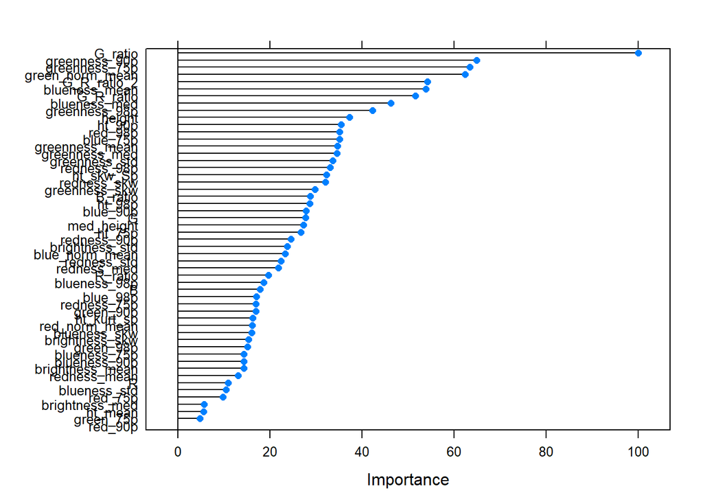

```r
plot(var_imp) # all
```

```r
rf_results <- bind_rows(res_rf_default, res_rf_mtry, res_rf_maxnode, res_rf_maxtrees, res_rf_fit) %>%
  dplyr::select(model, mtry, Accuracy, Kappa)
rf_results
```

```
##         model mtry  Accuracy     Kappa
## 1  rf_default   27 0.8466667 0.6827506
## 2     rf_mtry   16 0.8766667 0.7424242
## 3  rf_maxnode   16 0.8366667 0.6655012
## 4 rf_maxtrees   16 0.8233333 0.6442890
## 5      rf_fit   16 0.8500000 0.6878788
```

```r
rf_pred_results <- bind_rows(mat_rf, mat_rf_mtry, mat_rf_maxnode, mat_rf_maxtrees, mat_rf_fit) %>%
  dplyr::select(model, Accuracy, Kappa)
rf_pred_results
```

```
##         model  Accuracy     Kappa
## 1  rf_default 0.9166667 0.8139535
## 2     rf_mtry 0.8750000 0.7096774
## 3  rf_maxnode 0.9166667 0.7983193
## 4 rf_maxtrees 0.9166667 0.7983193
## 5      rf_fit 0.9583333 0.9032258
```

## Support Vector Machine

| model | Accuracy | Kappa | C | sigma |
| --- | --- | --- | --- | --- |
| svm_Linear | 0.7566667 | 0.5128205 | 1.0000000 | NA |
| svm_Linear_Grid | 0.8366667 | 0.6724942 | 0.1052632 | NA |
| svm_Radial | 0.8500000 | 0.6872960 | 0.5000000 | 0.01763192 |
| **svm_Radial_Grid** | **0.9133333** | **0.8212121** | **0.2105263** | **0.010** |

However, when we ran the models against our test set, our svm_Linear_Grid model performed better with about 95.83% accuracy and 90.32% kappa.

| model | Accuracy | Kappa |
| --- | --- | --- |
| svm_Linear | 0.7916667 | 0.5833333 |
| **svm_Linear_Grid** | **0.9583333** | **0.9032258** |
| svm_Radial | 0.9166667 | 0.7983193 |
| svm_Radial_Grid | 0.9166667 | 0.7983193 |

Accuracy Assessment for svm_Linear_Grid model:

| Status | Producer’s Accuracy | Omission | User’s Accuracy | Commission |
| --- | --- | --- | --- | --- |
| Alive | 0.94117647 | 0.05882353 | 1 | 0 |
| Dead | 1 | 0 | 0.875 | 0.125 |

```r
# Preparing Datasets ----
set.seed(1)

training <- sample(1:nrow(model_df), 0.7*nrow(model_df))
train_set <- model_df[training,]
test_set <- model_df[-training,]

set.seed(1)

trctrl <- trainControl(method = "CV", number = 10)

# Linear
svm_Linear <- train(status ~., data = train_set, method = "svmLinear",
                    trControl=trctrl,
                    preProcess = c("center", "scale"),
                    tuneLength = 10)

svm_Linear # Accuracy=0.7566667 and Kappa=0.5128205
```

```
## Support Vector Machines with Linear Kernel
##
## 56 samples
## 53 predictors
##  2 classes: 'A', 'D'
##
## Pre-processing: centered (53), scaled (53)
## Resampling: Cross-Validated (10 fold)
## Summary of sample sizes: 50, 50, 51, 50, 50, 51, ...
## Resampling results:
##
##   Accuracy   Kappa
##   0.7566667  0.5128205
##
## Tuning parameter 'C' was held constant at a value of 1
```

```r
res_svm_Linear <- as_tibble(svm_Linear$results[which.max(svm_Linear$results[,2]),]) %>%
  mutate(model = "svm_Linear") %>% as.data.frame()

test_pred <- predict(svm_Linear, newdata = test_set)
test_pred
```

```
##  [1] D D A D D D A A A D A D A A D A D A A D D A D A
## Levels: A D
```

```r
mat_Linear <- confusionMatrix(table(test_pred, test_set$status))$overall %>%
  t() %>%
  as.data.frame() %>%
  mutate(model = "svm_Linear")
mat_Linear # Accuracy=0.7916667 and Kappa=0.5833333
```

```
##    Accuracy     Kappa AccuracyLower AccuracyUpper AccuracyNull AccuracyPValue
## 1 0.7916667 0.5833333     0.5784872     0.9286814    0.7083333      0.2564379
##   McnemarPValue      model
## 1    0.07363827 svm_Linear
```

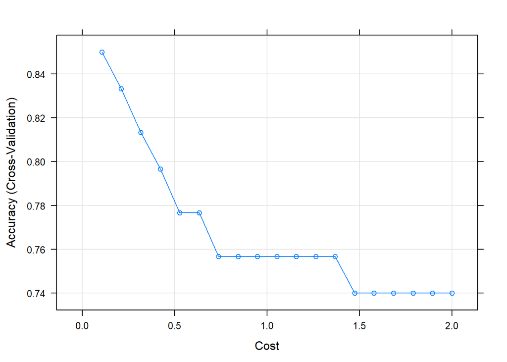

```r
# Linear Grid
set.seed(1)

grid <- expand.grid(C = seq(0, 2, length = 20))
svm_Linear_Grid <- train(status ~., data = train_set, method = "svmLinear",
                         trControl=trctrl,
                         preProcess = c("center", "scale"),
                         tuneGrid = grid,
                         tuneLength = 10)

# svm_Linear_Grid # C=0.1052632, Accuracy=0.8500000 and Kappa=0.6948718
plot(svm_Linear_Grid)
```

```r
grid <- expand.grid(C = as.numeric(svm_Linear_Grid$results[,1]))
svm_Linear_Grid <- train(status ~., data = train_set, method = "svmLinear",
                         trControl=trctrl,
                         preProcess = c("center", "scale"),
                         tuneGrid = grid,
                         tuneLength = 10)

res_svm_Linear_Grid <- as_tibble(svm_Linear_Grid$results[which.max(svm_Linear_Grid$results[,2]),]) %>%
  mutate(model = "svm_Linear_Grid") %>% as.data.frame()

test_pred_grid <- predict(svm_Linear_Grid, newdata = test_set)
test_pred_grid
```

```
##  [1] D A A D D D A A A A A D A A A A A A A D D A D A
## Levels: A D
```

```r
mat_Linear_Grid <- confusionMatrix(table(test_pred_grid, test_set$status))$overall %>%
  t() %>%
  as.data.frame() %>%
  mutate(model = "svm_Linear_Grid")
mat_Linear_Grid # Accuracy=0.9583333 and Kappa=0.9032258
```

```
##    Accuracy     Kappa AccuracyLower AccuracyUpper AccuracyNull AccuracyPValue
## 1 0.9583333 0.9032258     0.7887983     0.9989456    0.7083333    0.002769664
##   McnemarPValue           model
## 1             1 svm_Linear_Grid
```

```r
conf_Linear_Grid <- confusionMatrix(table(test_pred_grid, test_set$status))$table
conf_Linear_Grid
```

```
##
## test_pred_grid  A  D
##              A 16  0
##              D  1  7
```

```r
c("A Producer's Accuracy"=conf_Linear_Grid[1,1]/sum(conf_Linear_Grid[,1]),"A Omission"=1-(conf_Linear_Grid[1,1]/sum(conf_Linear_Grid[,1]))) # 94.12% (5.88%)
```

```
## A Producer's Accuracy            A Omission
##            0.94117647            0.05882353
```

```r
c("D Producer's Accuracy"=conf_Linear_Grid[2,2]/sum(conf_Linear_Grid[,2]),"D Omission"=1-(conf_Linear_Grid[2,2]/sum(conf_Linear_Grid[,2]))) # 100% (0%)
```

```
## D Producer's Accuracy            D Omission
##                     1                     0
```

```r
c("A User's Accuracy"=conf_Linear_Grid[1,1]/sum(conf_Linear_Grid[1,]),"A Commission"=1-(conf_Linear_Grid[1,1]/sum(conf_Linear_Grid[1,]))) # 100% (0%)
```

```
## A User's Accuracy      A Commission
##                 1                 0
```

```r
c("D User's Accuracy"=conf_Linear_Grid[2,2]/sum(conf_Linear_Grid[2,]),"D Commission"=1-(conf_Linear_Grid[2,2]/sum(conf_Linear_Grid[2,]))) # 87.5% (12.5%)
```

```
## D User's Accuracy      D Commission
##             0.875             0.125
```

```r
# Radial
set.seed(1)

svm_Radial <- train(status ~., data = train_set, method = "svmRadial",
                    trControl = trctrl,
                    preProcess = c("center","scale"),
                    tuneLength = 10)
svm_Radial # C=0.50, Accuracy=0.8500000 and Kappa=0.6872960
```

```
## Support Vector Machines with Radial Basis Function Kernel
##
## 56 samples
## 53 predictors
##  2 classes: 'A', 'D'
##
## Pre-processing: centered (53), scaled (53)
## Resampling: Cross-Validated (10 fold)
## Summary of sample sizes: 50, 50, 51, 50, 50, 51, ...
## Resampling results across tuning parameters:
##
##   C       Accuracy   Kappa
##     0.25  0.8366667  0.6660839
##     0.50  0.8500000  0.6872960
##     1.00  0.8300000  0.6494172
##     2.00  0.7933333  0.5831169
##     4.00  0.7766667  0.5497835
##     8.00  0.7233333  0.4452381
##    16.00  0.7433333  0.4782051
##    32.00  0.7433333  0.4782051
##    64.00  0.7433333  0.4782051
##   128.00  0.7433333  0.4782051
##
## Tuning parameter 'sigma' was held constant at a value of 0.01763192
## Accuracy was used to select the optimal model using the largest value.
## The final values used for the model were sigma = 0.01763192 and C = 0.5.
```

```r
res_svm_Radial <- as_tibble(svm_Radial$results[which.max(svm_Radial$results[,3]),]) %>%
  mutate(model = "svm_Radial") %>% as.data.frame()

svm_Radial$bestTune # C=0.5
```

```
##        sigma   C
## 2 0.01763192 0.5
```

```r
test_pred_radial <- predict(svm_Radial, newdata = test_set)
test_pred_radial
```

```
##  [1] D A A D D D A A A A A D A A A A A A A A D A D A
## Levels: A D
```

```r
mat_Radial <- confusionMatrix(table(test_pred_radial, test_set$status))$overall %>%
  t() %>%
  as.data.frame() %>%
  mutate(model = "svm_Radial")
mat_Radial # Accuracy=0.9166667 and Kappa=0.7983193
```

```
##    Accuracy     Kappa AccuracyLower AccuracyUpper AccuracyNull AccuracyPValue
## 1 0.9166667 0.7983193     0.7300272     0.9897437    0.7083333     0.01467966
##   McnemarPValue      model
## 1             1 svm_Radial
```

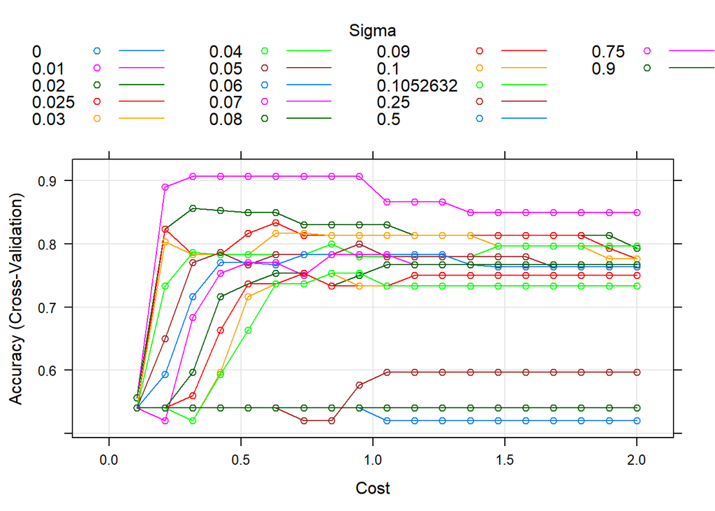

```r
# Radial Grid
set.seed(1)

grid_radial <- expand.grid(sigma = c(0, 0.01, 0.1052632, 0.02, 0.025, 0.03, 0.04,
                                       0.05, 0.06, 0.07,0.08, 0.09, 0.1, 0.25, 0.5, 0.75, 0.9),
                             C = seq(0, 2, length = 20))
svm_Radial_Grid <- train(status ~., data = train_set, method = "svmRadial",
                           trControl=trctrl,
                           preProcess = c("center", "scale"),
                           tuneGrid = grid_radial,
                           tuneLength = 10)

# svm_Radial_Grid # sigma=0.01, c=0.3157895, Accuracy=0.9066667 and Kappa=0.8045455


plot(svm_Radial_Grid)
```

```r
grid_radial <- expand.grid(sigma = as.numeric(svm_Radial_Grid$results[,1]),
                             C = as.numeric(svm_Radial_Grid$results[,2]))
svm_Radial_Grid <- train(status ~., data = train_set, method = "svmRadial",
                           trControl=trctrl,
                           preProcess = c("center", "scale"),
                           tuneGrid = grid_radial,
                           tuneLength = 10)


res_svm_Radial_Grid <- as_tibble(svm_Radial_Grid$results[which.max(svm_Radial_Grid$results[,3]),]) %>%
  mutate(model = "svm_Radial_Grid") %>% as.data.frame() # sigma=0.01 and C=0.3157895

test_pred_Radial_Grid <- predict(svm_Radial_Grid, newdata = test_set)
test_pred_Radial_Grid
```

```
##  [1] D A A D D D A A A A A D A A A A A A A A D A D A
## Levels: A D
```

```r
mat_Radial_Grid <- confusionMatrix(test_pred_Radial_Grid, test_set$status)$overall %>%
  t() %>%
  as.data.frame() %>%
  mutate(model = "svm_Radial_Grid")
mat_Radial_Grid # Accuracy=0.9166667 and Kappa=0.7983193
```

```
##    Accuracy     Kappa AccuracyLower AccuracyUpper AccuracyNull AccuracyPValue
## 1 0.9166667 0.7983193     0.7300272     0.9897437    0.7083333     0.01467966
##   McnemarPValue           model
## 1             1 svm_Radial_Grid
```

```r
svm_results <- bind_rows(res_svm_Linear, res_svm_Linear_Grid, res_svm_Radial, res_svm_Radial_Grid) %>%
  dplyr::select(model, C:sigma)
svm_results
```

```
##             model         C  Accuracy     Kappa AccuracySD   KappaSD      sigma
## 1      svm_Linear 1.0000000 0.7566667 0.5128205 0.20490889 0.4075319         NA
## 2 svm_Linear_Grid 0.1052632 0.8366667 0.6724942 0.05973191 0.1217253         NA
## 3      svm_Radial 0.5000000 0.8500000 0.6872960 0.14677605 0.3042869 0.01763192
## 4 svm_Radial_Grid 0.2105263 0.9133333 0.8212121 0.14418781 0.2936077 0.01000000
```

```r
svm_pred_results <- bind_rows(mat_Linear, mat_Linear_Grid, mat_Radial, mat_Radial_Grid) %>%
  dplyr::select(model, Accuracy, Kappa)
svm_pred_results
```

```
##             model  Accuracy     Kappa
## 1      svm_Linear 0.7916667 0.5833333
## 2 svm_Linear_Grid 0.9583333 0.9032258
## 3      svm_Radial 0.9166667 0.7983193
## 4 svm_Radial_Grid 0.9166667 0.7983193
```